# Modeling

Data Dive_rse - Kalyani Joshi, Che Diaz Fadel, Disha Tapadiya and Debayan Dutta

2023-11-05

```r
# Load packages
library(forecast)
library(prophet)
library(e1071)
library(tidyverse)
library(lubridate)
library(dplyr)
library(vars)
library(mFilter)
library(forecast)
library(fpp3)
library(doParallel)
library(caret)
library(xgboost)
```

# Introduction

Project Goal: Maverik is interested in producing more accurate financial plans and initial ROI documents for future convenience store locations.The goal of this project is to develop a predictive model that is precise enough for forecasting the first-year sales of new stores that Maverik plans to open.This predictive model will be an ensemble of forecasting and supervised regression models designed to provide daily store level sales forecasts of multiple key product categories and aid Maverik in financial planning, resource allocation, and ROI calculations for its expansion strategy. The Success of this project will be benchmarked against Maverik’s existing Naive forecasting solution. The ability to accurately forecast store sales will enable Maverik to optimize the expenditure of scarce resources by pursuing the most profitable locations and minimizing misallocation of said resources when opening a new store. This will lead to better investment, decreased waste, and more reliable financial evaluations.

#### Business Problems

Maverik aims to open 30 new stores annually and requires an accurate predictive model for the first-year sales to support financial planning and ROI calculations.

#### Benefits of the Solution

Precise forecasts will enable them to make informed decisions on store locations and resource allocation along with achieving set sales targets while checking the progress.

#### Success Matrix

The solution provided will be considered a success if it generates forecasts accurate to within 10% of actual sales, can update forecasts based on new data along with being user-friendly and easy to support.

#### Analytical Approach

Four models will be developed to leverage Maverik’s historical sales data: Vector AutoRegressive Model, Prophet, Support Vector Regression, and Extreme Gradient Boosting. Each model will be tuned to minimize RMSE, which will be the metric used to select the final model.

# Vector AutoRegressive Model (VAR)

## Preparing data

```r
# Load data
t<- read.csv("t_series.csv")
t$open_date <- as.Date(t$open_date)
t$date <- as.Date(t$date)
```

### Spiltting data into train and test

```r
set.seed(1234)

t_sites <- sample(unique(t$site_id), 30)

train_sales <- t %>%   filter(site_id %in% t_sites)
test_sales <- t %>%   filter(!site_id %in% t_sites)
```

We are choosing 30 unique site_id’s in train data and remaining in test data

### Creating time series

**Train Data**

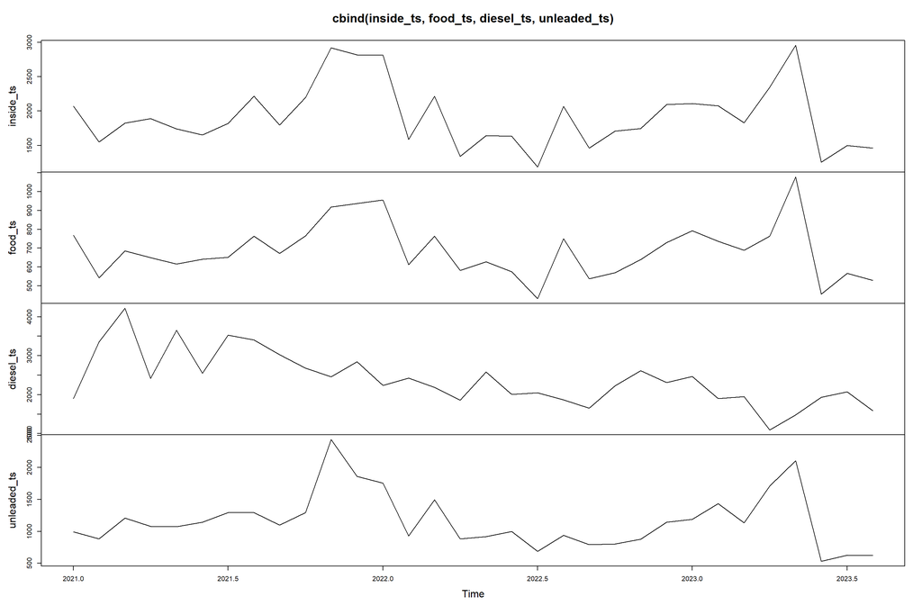

```r
inside_ts <- ts(train_sales$inside_sales, start=c(2021,01), end = c(2023,8), frequency = 12)
food_ts <- ts(train_sales$food_service_sales, start=c(2021,01), end = c(2023,8), frequency = 12)
diesel_ts <- ts(train_sales$diesel_sales, start=c(2021,01), end = c(2023,8), frequency = 12)
unleaded_ts <- ts(train_sales$unleaded_sales, start=c(2021,01), end = c(2023,8), frequency = 12)
plot(cbind(inside_ts,food_ts,diesel_ts,unleaded_ts))
```

```r
# Combining ts objects
sales_train <- cbind(inside_ts, food_ts, diesel_ts, unleaded_ts)
colnames(sales_train) <- c("inside_ts", "food_ts", "diesel_ts", "unleaded_ts")
```

Above plot shows both trend and seasonality in the data.

**Test Data**

```r
inside_ts_test <- ts(test_sales$inside_sales, start = c(2021, 01), end = c(2023, 8), frequency = 12)
food_ts_test <- ts(test_sales$food_service_sales, start = c(2021, 01), end = c(2023, 8), frequency = 12)
diesel_ts_test <- ts(test_sales$diesel_sales, start = c(2021, 01), end = c(2023, 8), frequency = 12)
unleaded_ts_test <- ts(test_sales$unleaded_sales, start = c(2021, 01), end = c(2023, 8), frequency = 12)

# Combining ts objects
sales_test <- cbind(inside_ts_test, food_ts_test, diesel_ts_test, unleaded_ts_test)
colnames(sales_test) <- c("inside_ts_test", "food_ts_test", "diesel_ts_test", "unleaded_ts_test")
```

## ACF Plots

**Inside Sales**

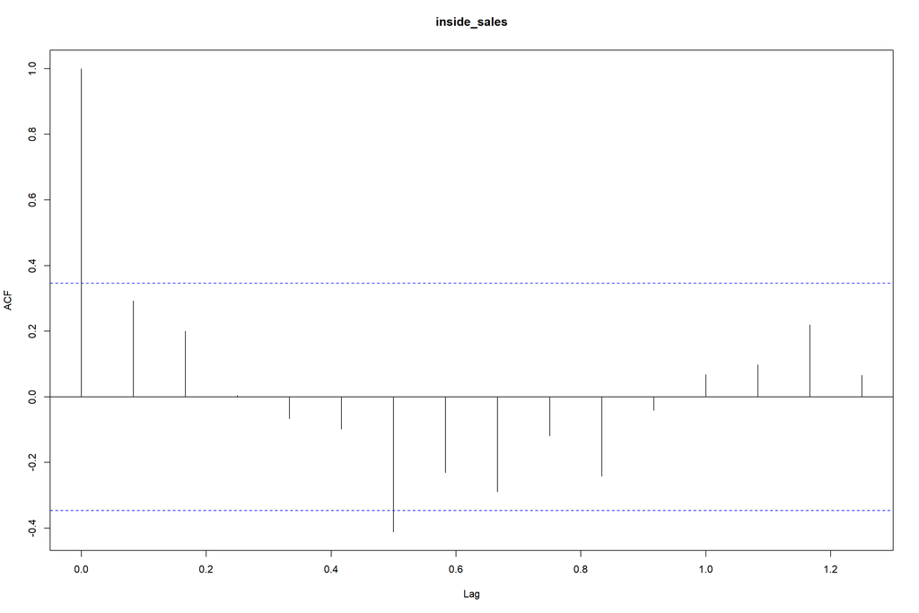

```r
inside.acf <- acf(inside_ts, main = "inside_sales")
```

```r
adf_inside <- ur.df(inside_ts, type = "trend", selectlags = "AIC")
summary(adf_inside)
```

```
##
## ###############################################
## # Augmented Dickey-Fuller Test Unit Root Test #
## ###############################################
##
## Test regression trend
##
##
## Call:
## lm(formula = z.diff ~ z.lag.1 + 1 + tt + z.diff.lag)
##
## Residuals:
##     Min      1Q  Median      3Q     Max
## -922.13 -246.57  -77.99  280.10 1007.39
##
## Coefficients:
##              Estimate Std. Error t value Pr(>|t|)
## (Intercept) 1245.1338   488.3419   2.550   0.0170 *
## z.lag.1       -0.5902     0.2324  -2.540   0.0174 *
## tt            -6.6482     9.9542  -0.668   0.5101
## z.diff.lag    -0.1391     0.1944  -0.715   0.4809
## ---
## Signif. codes:  0 '***' 0.001 '**' 0.01 '*' 0.05 '.' 0.1 ' ' 1
##
## Residual standard error: 471.7 on 26 degrees of freedom
## Multiple R-squared:  0.3645, Adjusted R-squared:  0.2912
## F-statistic: 4.971 on 3 and 26 DF,  p-value: 0.007379
##
##
## Value of test-statistic is: -2.5399 2.3029 3.4457
##
## Critical values for test statistics:
##       1pct  5pct 10pct
## tau3 -4.15 -3.50 -3.18
## phi2  7.02  5.13  4.31
## phi3  9.31  6.73  5.61
```

The F-statistic evaluates the overall significance of the model. In this instance, it has a value of 4.971, with a low p-value, indicating that the model is statistically significant.

**Food Sales**

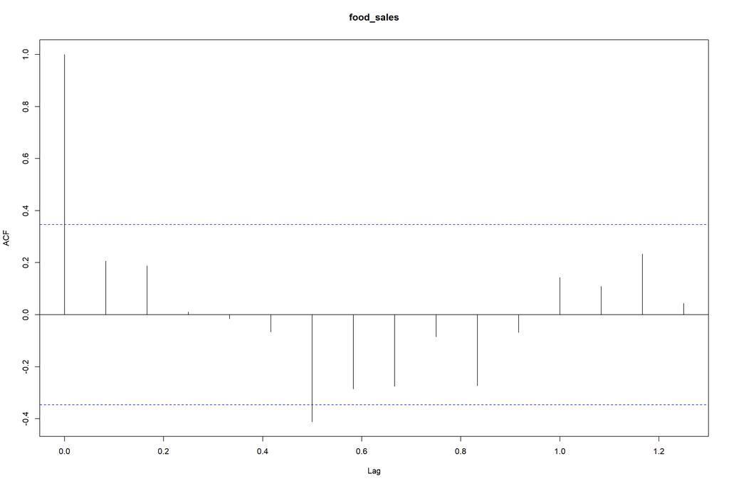

```r
food.acf <- acf(food_ts, main = "food_sales")
```

```r
adf_food <- ur.df(food_ts, type = "trend", selectlags = "AIC")
summary(adf_food)
```

```
##
## ###############################################
## # Augmented Dickey-Fuller Test Unit Root Test #
## ###############################################
##
## Test regression trend
##
##
## Call:
## lm(formula = z.diff ~ z.lag.1 + 1 + tt + z.diff.lag)
##
## Residuals:
##     Min      1Q  Median      3Q     Max
## -299.60  -86.44  -25.34   81.40  398.00
##
## Coefficients:
##             Estimate Std. Error t value Pr(>|t|)
## (Intercept) 465.9202   177.7706   2.621   0.0145 *
## z.lag.1      -0.6293     0.2443  -2.576   0.0160 *
## tt           -2.0140     3.1060  -0.648   0.5224
## z.diff.lag   -0.1648     0.1923  -0.857   0.3993
## ---
## Signif. codes:  0 '***' 0.001 '**' 0.01 '*' 0.05 '.' 0.1 ' ' 1
##
## Residual standard error: 147.2 on 26 degrees of freedom
## Multiple R-squared:  0.4065, Adjusted R-squared:  0.338
## F-statistic: 5.935 on 3 and 26 DF,  p-value: 0.003177
##
##
## Value of test-statistic is: -2.5757 2.3881 3.5729
##
## Critical values for test statistics:
##       1pct  5pct 10pct
## tau3 -4.15 -3.50 -3.18
## phi2  7.02  5.13  4.31
## phi3  9.31  6.73  5.61
```

**Diesel Sales**

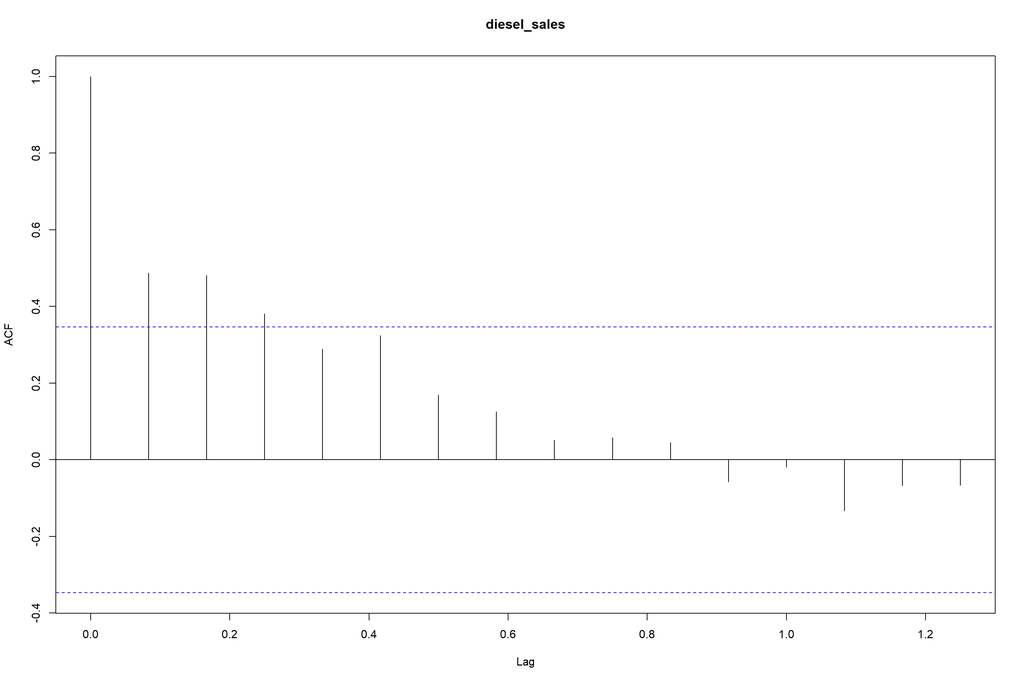

```r
diesel.acf <- acf(diesel_ts, main = "diesel_sales")
```

```r
adf_diesel <- ur.df(diesel_ts, type = "trend", selectlags = "AIC")
summary(adf_diesel)
```

```
##
## ###############################################
## # Augmented Dickey-Fuller Test Unit Root Test #
## ###############################################
##
## Test regression trend
##
##
## Call:
## lm(formula = z.diff ~ z.lag.1 + 1 + tt + z.diff.lag)
##
## Residuals:
##     Min      1Q  Median      3Q     Max
## -689.89 -349.60   70.05  337.05  961.09
##
## Coefficients:
##               Estimate Std. Error t value Pr(>|t|)
## (Intercept) 3634.19973  930.22811   3.907 0.000596 ***
## z.lag.1       -1.08341    0.27004  -4.012 0.000453 ***
## tt           -63.90783   18.30120  -3.492 0.001731 **
## z.diff.lag     0.02066    0.17202   0.120 0.905325
## ---
## Signif. codes:  0 '***' 0.001 '**' 0.01 '*' 0.05 '.' 0.1 ' ' 1
##
## Residual standard error: 462.1 on 26 degrees of freedom
## Multiple R-squared:  0.5307, Adjusted R-squared:  0.4766
## F-statistic: 9.802 on 3 and 26 DF,  p-value: 0.0001682
##
##
## Value of test-statistic is: -4.0121 5.5246 8.0661
##
## Critical values for test statistics:
##       1pct  5pct 10pct
## tau3 -4.15 -3.50 -3.18
## phi2  7.02  5.13  4.31
## phi3  9.31  6.73  5.61
```

**Unleaded Sales**

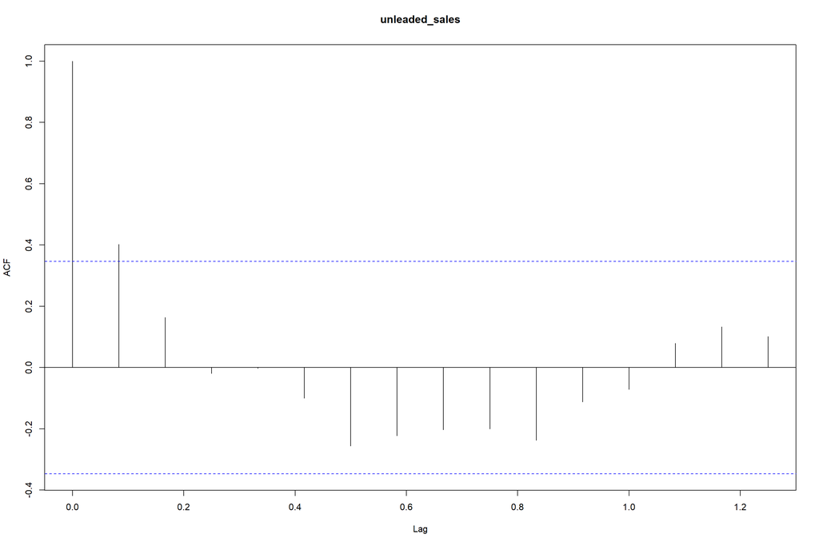

```r
unleaded.acf <- acf(unleaded_ts, main = "unleaded_sales")
```

```r
adf_unleaded <- ur.df(unleaded_ts, type = "trend", selectlags = "AIC")
summary(adf_unleaded)
```

```
##
## ###############################################
## # Augmented Dickey-Fuller Test Unit Root Test #
## ###############################################
##
## Test regression trend
##
##
## Call:
## lm(formula = z.diff ~ z.lag.1 + 1 + tt + z.diff.lag)
##
## Residuals:
##     Min      1Q  Median      3Q     Max
## -900.75 -198.04  -57.67  138.40 1157.21
##
## Coefficients:
##              Estimate Std. Error t value Pr(>|t|)
## (Intercept) 839.33953  318.40780   2.636   0.0140 *
## z.lag.1      -0.58687    0.21900  -2.680   0.0126 *
## tt           -9.21487    8.91829  -1.033   0.3110
## z.diff.lag   -0.02816    0.19871  -0.142   0.8884
## ---
## Signif. codes:  0 '***' 0.001 '**' 0.01 '*' 0.05 '.' 0.1 ' ' 1
##
## Residual standard error: 419.8 on 26 degrees of freedom
## Multiple R-squared:  0.3105, Adjusted R-squared:  0.2309
## F-statistic: 3.902 on 3 and 26 DF,  p-value: 0.01995
##
##
## Value of test-statistic is: -2.6798 2.6368 3.9417
##
## Critical values for test statistics:
##       1pct  5pct 10pct
## tau3 -4.15 -3.50 -3.18
## phi2  7.02  5.13  4.31
## phi3  9.31  6.73  5.61
```

## Model Fitting

**Choosing lags to implement VAR model**

```r
info_sales_train <- VARselect(sales_train, lag.max = 10, type = "none")
info_sales_train$selection
```

```
## AIC(n)  HQ(n)  SC(n) FPE(n)
##      6      6      6      6
```

The VARselect function recommends a lag order of 6 for a Vector Autoregression (VAR) model on the “sales_train” dataset based on multiple information criteria, including AIC, HQ, SC, and FPE. This choice aims to strike a balance between model complexity and goodness of fit.

**Fitting VAR model on Train data**

```r
sales_train_est <- VAR(sales_train, p = 5, type = "none", season = NULL, exog = NULL)
summary(sales_train_est)
```

```
##
## VAR Estimation Results:
## =========================
## Endogenous variables: inside_ts, food_ts, diesel_ts, unleaded_ts
## Deterministic variables: none
## Sample size: 27
## Log Likelihood: -636.192
## Roots of the characteristic polynomial:
## 1.052 1.052 1.042 1.042 0.9984 0.9569 0.9569 0.9454 0.9454 0.9398 0.9057 0.9057 0.8899 0.8899 0.8184 0.8046 0.8046 0.6965 0.6965 0.3019
## Call:
## VAR(y = sales_train, p = 5, type = "none", exogen = NULL)
##
##
## Estimation results for equation inside_ts:
## ==========================================
## inside_ts = inside_ts.l1 + food_ts.l1 + diesel_ts.l1 + unleaded_ts.l1 + inside_ts.l2 + food_ts.l2 + diesel_ts.l2 + unleaded_ts.l2 + inside_ts.l3 + food_ts.l3 + diesel_ts.l3 + unleaded_ts.l3 + inside_ts.l4 + food_ts.l4 + diesel_ts.l4 + unleaded_ts.l4 + inside_ts.l5 + food_ts.l5 + diesel_ts.l5 + un…
##
##                 Estimate Std. Error t value Pr(>|t|)
## inside_ts.l1    2.525123   1.947113   1.297    0.236
## food_ts.l1     -6.759437   3.970384  -1.702    0.132
## diesel_ts.l1   -0.136821   0.402628  -0.340    0.744
## unleaded_ts.l1 -0.446114   1.470191  -0.303    0.770
## inside_ts.l2   -0.721842   1.631657  -0.442    0.672
## food_ts.l2      1.376699   4.102316   0.336    0.747
## diesel_ts.l2    0.007008   0.459072   0.015    0.988
## unleaded_ts.l2  0.481895   0.908350   0.531    0.612
## inside_ts.l3    1.404188   1.525867   0.920    0.388
## food_ts.l3     -1.215320   3.772417  -0.322    0.757
## diesel_ts.l3    0.502640   0.356510   1.410    0.201
## unleaded_ts.l3 -1.275459   0.835377  -1.527    0.171
## inside_ts.l4   -1.342801   1.702937  -0.789    0.456
## food_ts.l4      6.278383   4.843092   1.296    0.236
## diesel_ts.l4   -0.136371   0.312869  -0.436    0.676
## unleaded_ts.l4  0.026408   0.972489   0.027    0.979
## inside_ts.l5    0.614122   2.172163   0.283    0.786
## food_ts.l5     -1.507211   6.351803  -0.237    0.819
## diesel_ts.l5    0.107944   0.342509   0.315    0.762
## unleaded_ts.l5 -0.827422   0.909132  -0.910    0.393
##
##
```

[output cut: 104 more lines]

```
##
##
## Covariance matrix of residuals:
##             inside_ts food_ts diesel_ts unleaded_ts
## inside_ts      320883   86659    -43135      273510
## food_ts         86659   24757     -2911       71175
## diesel_ts      -43135   -2911    203981      -53119
## unleaded_ts    273510   71175    -53119      250848
##
## Correlation matrix of residuals:
##             inside_ts  food_ts diesel_ts unleaded_ts
## inside_ts      1.0000  0.97228  -0.16860      0.9640
## food_ts        0.9723  1.00000  -0.04097      0.9032
## diesel_ts     -0.1686 -0.04097   1.00000     -0.2348
## unleaded_ts    0.9640  0.90318  -0.23483      1.0000
```

The residual correlation matrix shows that the correlation between the residuals of inside_ts and unleaded_ts is 0.9640, which is very high. This suggests that the two variables share a lot of common information.

**Performing Portmanteau-test on model Residuals for train data**

```r
train_serial <- serial.test(sales_train_est, lags.pt = 19, type = "PT.asymptotic")
train_serial
```

```
##
##  Portmanteau Test (asymptotic)
##
## data:  Residuals of VAR object sales_train_est
## Chi-squared = 249.51, df = 224, p-value = 0.1163
```

In the case of the VAR model for the sales data, the Portmanteau test statistic is 249.51 with 224 degrees of freedom. The p-value is 0.1163, which is greater than the significance level of 0.05. This means that we fail to reject the null hypothesis of no autocorrelation in the residuals.

The Portmanteau test suggests that there is no evidence of autocorrelation in the residuals of the VAR model. This is a good sign, as it means that the VAR model is a good fit for the data.

**Residual plots for each sales metrics**

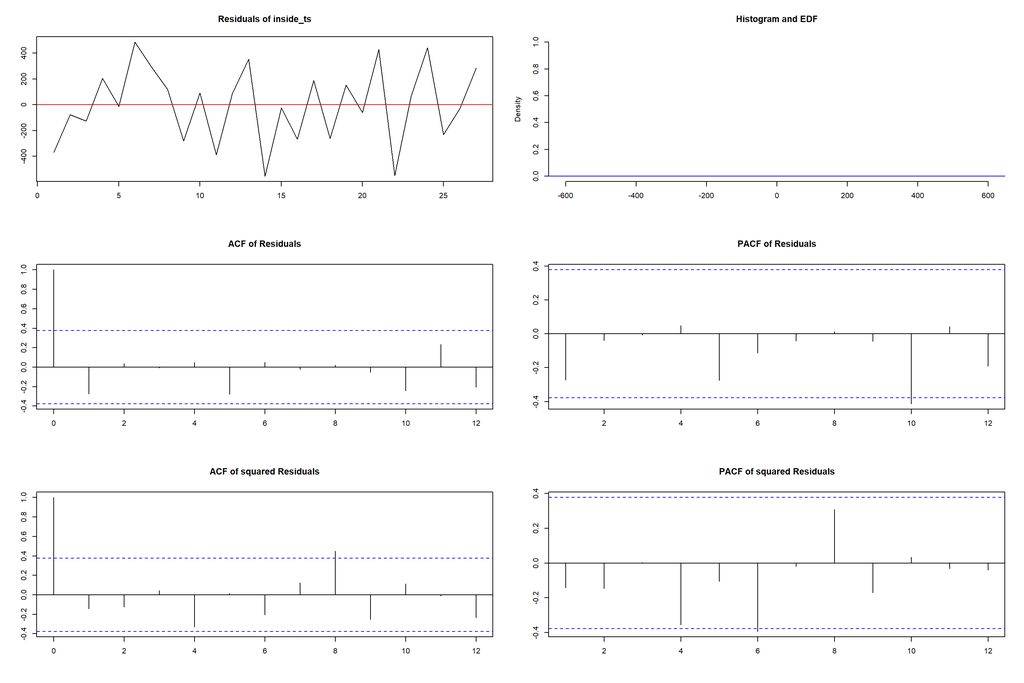

```r
plot(train_serial, names = "inside_ts")
```

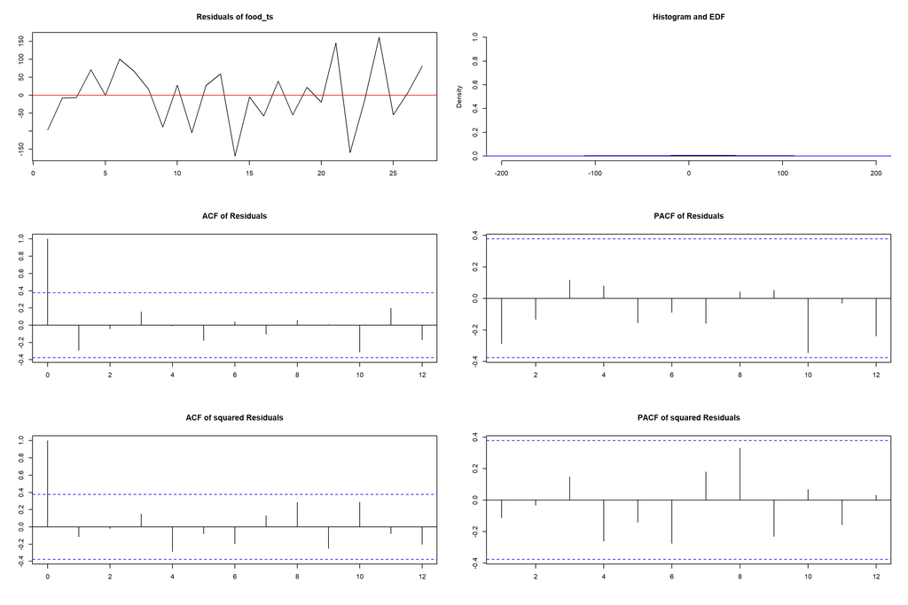

```r
plot(train_serial, names = "food_ts")
```

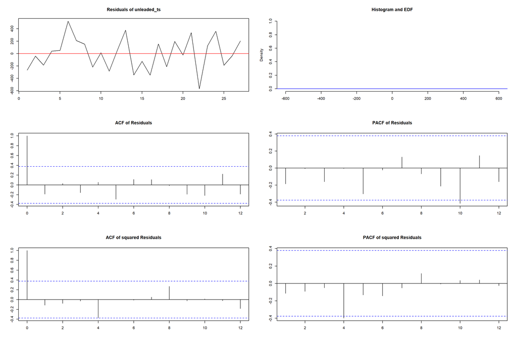

```r
plot(train_serial, names = "unleaded_ts")
```

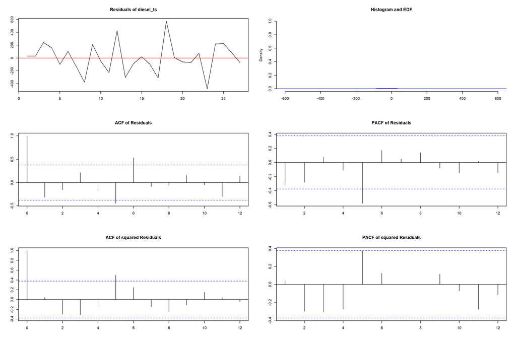

```r
plot(train_serial, names = "diesel_ts")
```

The residual plots show that the residuals of the VAR model are randomly scattered around the zero line, with no obvious patterns or outliers. This suggests that the VAR model is a good fit for the data.

**Granger causality Check to check variables’ causality**

```r
train_cause_inside_ts <- causality(sales_train_est, cause = "inside_ts")
train_cause_inside_ts
```

```
## $Granger
##
##  Granger causality H0: inside_ts do not Granger-cause food_ts diesel_ts
##  unleaded_ts
##
## data:  VAR object sales_train_est
## F-Test = 1.0403, df1 = 15, df2 = 28, p-value = 0.4473
##
##
## $Instant
##
##  H0: No instantaneous causality between: inside_ts and food_ts diesel_ts
##  unleaded_ts
##
## data:  VAR object sales_train_est
## Chi-squared = 13.412, df = 3, p-value = 0.003825
```

```r
train_cause_food_ts <- causality(sales_train_est, cause = "food_ts")
train_cause_food_ts
```

```
## $Granger
##
##  Granger causality H0: food_ts do not Granger-cause inside_ts diesel_ts
##  unleaded_ts
##
## data:  VAR object sales_train_est
## F-Test = 1.1496, df1 = 15, df2 = 28, p-value = 0.3623
##
##
## $Instant
##
##  H0: No instantaneous causality between: food_ts and inside_ts diesel_ts
##  unleaded_ts
##
## data:  VAR object sales_train_est
## Chi-squared = 13.298, df = 3, p-value = 0.004035
```

```r
train_cause_diesel_ts <- causality(sales_train_est, cause = "diesel_ts")
train_cause_diesel_ts
```

```
## $Granger
##
##  Granger causality H0: diesel_ts do not Granger-cause inside_ts food_ts
##  unleaded_ts
##
## data:  VAR object sales_train_est
## F-Test = 2.9168, df1 = 15, df2 = 28, p-value = 0.006992
##
##
## $Instant
##
##  H0: No instantaneous causality between: diesel_ts and inside_ts food_ts
##  unleaded_ts
##
## data:  VAR object sales_train_est
## Chi-squared = 6.318, df = 3, p-value = 0.09712
```

```r
train_cause_unleaded_ts <- causality(sales_train_est, cause = "unleaded_ts")
train_cause_unleaded_ts
```

```
## $Granger
##
##  Granger causality H0: unleaded_ts do not Granger-cause inside_ts
##  food_ts diesel_ts
##
## data:  VAR object sales_train_est
## F-Test = 1.0638, df1 = 15, df2 = 28, p-value = 0.4281
##
##
## $Instant
##
##  H0: No instantaneous causality between: unleaded_ts and inside_ts
##  food_ts diesel_ts
##
## data:  VAR object sales_train_est
## Chi-squared = 13.159, df = 3, p-value = 0.004305
```

## Forecasting

```r
sales_test_forecast <- predict(sales_train_est, n.ahead = nrow(sales_test), ci = 0.95, dumvar = NULL, dumvar.forecast = NULL)
```

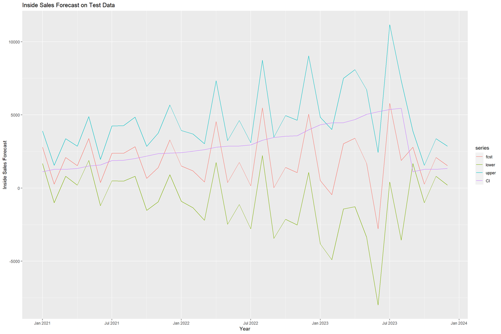

```r
# Extract forecasted values for each variable in test data
inside_forecast_values <- sales_test_forecast$fcst$inside_ts
food_forecast_values <- sales_test_forecast$fcst$food_ts
diesel_forecast_values <- sales_test_forecast$fcst$diesel_ts
unleaded_forecast_values <- sales_test_forecast$fcst$unleaded_ts

# Create time series for each forecasted variable in test data
inside_forecast_ts <- ts(inside_forecast_values, start = c(2021, 1), end = c(2023, 12), frequency = 12)
food_forecast_ts <- ts(food_forecast_values, start = c(2021, 1), end = c(2023, 12), frequency = 12)
diesel_forecast_ts <- ts(diesel_forecast_values, start = c(2021, 1), end = c(2023, 12), frequency = 12)
unleaded_forecast_ts <- ts(unleaded_forecast_values, start = c(2021, 1), end = c(2023, 12), frequency = 12)

# Create and display plots for each forecasted variable with months on x-axis on test data
autoplot(inside_forecast_ts, xlab = "Year", ylab = "Inside Sales Forecast", main = "Inside Sales Forecast on Test Data") +
  scale_x_yearmon()
```

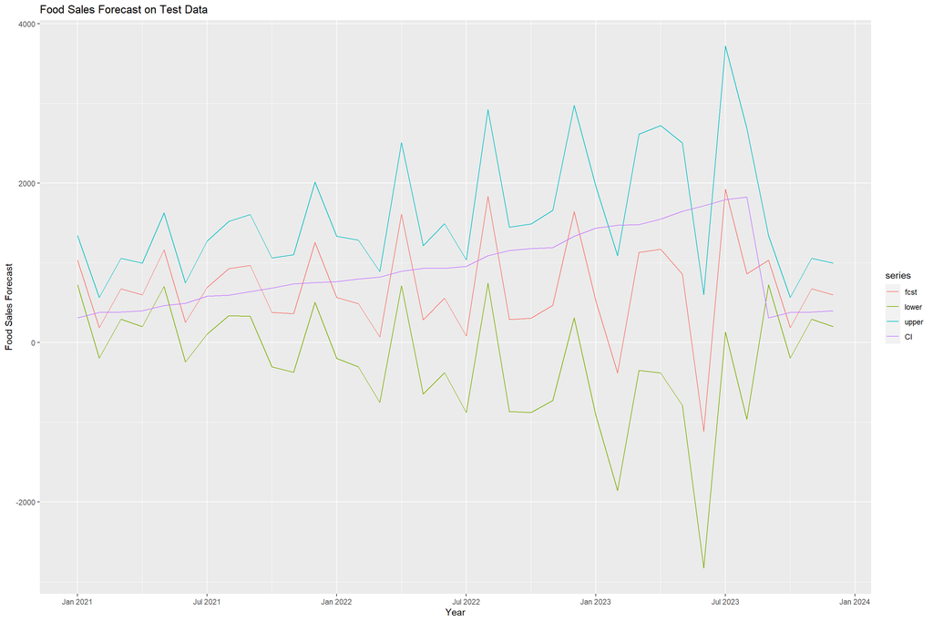

```r
autoplot(food_forecast_ts, xlab = "Year", ylab = "Food Sales Forecast", main = "Food Sales Forecast on Test Data") +
  scale_x_yearmon()
```

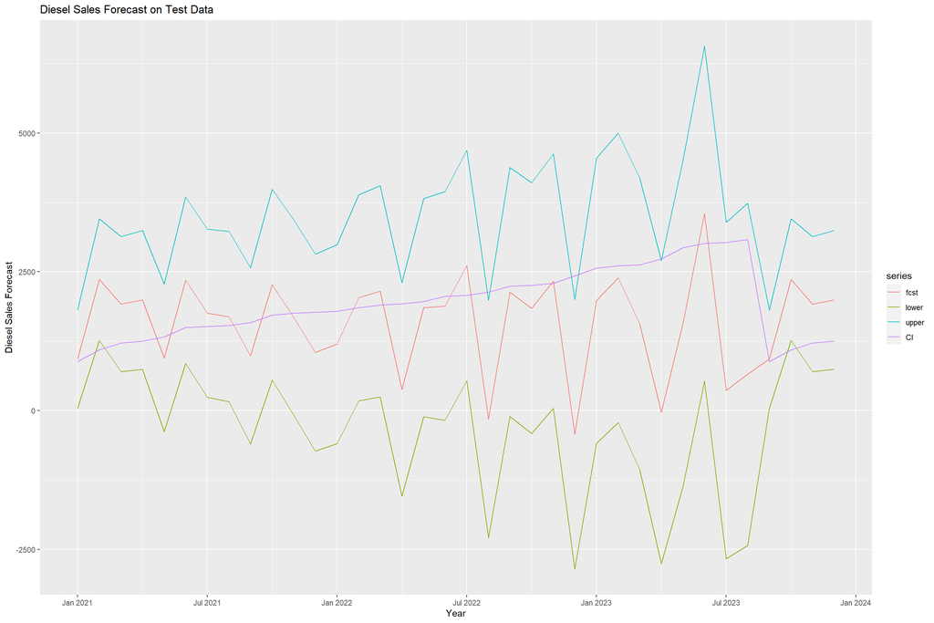

```r
autoplot(diesel_forecast_ts, xlab = "Year", ylab = "Diesel Sales Forecast", main = "Diesel Sales Forecast on Test Data") +
  scale_x_yearmon()
```

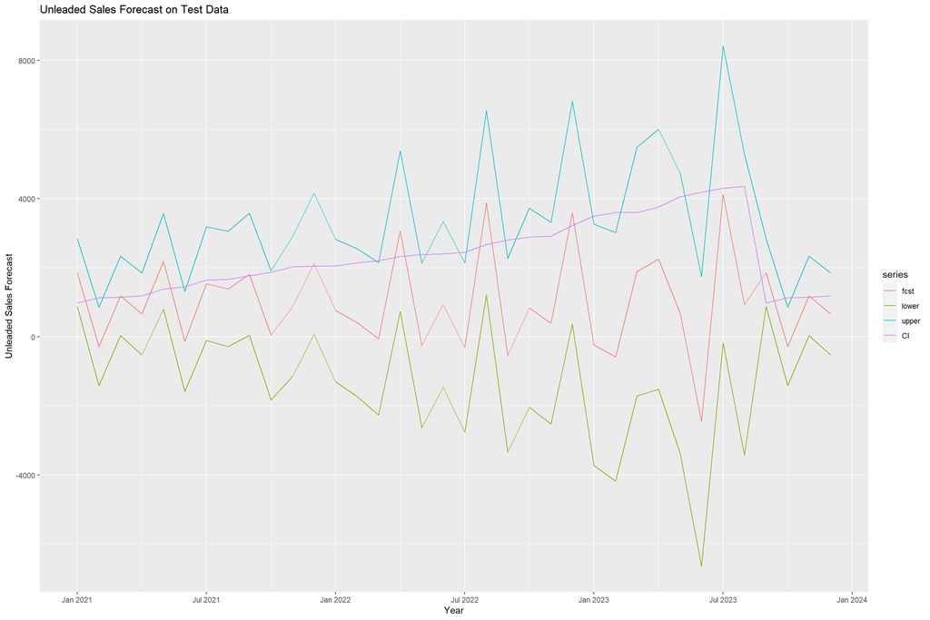

```r
autoplot(unleaded_forecast_ts, xlab = "Year", ylab = "Unleaded Sales Forecast", main = "Unleaded Sales Forecast on Test Data") +
  scale_x_yearmon()
```

## Model Evaluation

**Train Data**

```r
# Generate forecasts for the training data
train_forecast <- predict(sales_train_est, n.ahead = nrow(sales_train))

# Extract the actual and forecasted values for each response variable - train data
actual_train_inside <- sales_train[,"inside_ts"]
actual_train_food <- sales_train[,"food_ts"]
actual_train_diesel <- sales_train[,"diesel_ts"]
actual_train_unleaded <- sales_train[,"unleaded_ts"]

forecasted_train_inside <- train_forecast$fcst$inside_ts[,"fcst"]
forecasted_train_food <- train_forecast$fcst$food_ts[,"fcst"]
forecasted_train_diesel <- train_forecast$fcst$diesel_ts[,"fcst"]
forecasted_train_unleaded <- train_forecast$fcst$unleaded_ts[,"fcst"]

# Calculate residuals (errors) for each response variable - training dataset
train_inside_errors <- actual_train_inside - forecasted_train_inside
train_food_errors <- actual_train_food - forecasted_train_food
train_diesel_errors <- actual_train_diesel - forecasted_train_diesel
train_unleaded_errors <- actual_train_unleaded - forecasted_train_unleaded

# Calculate MAE for each response variable - training dataset
mae_train_inside <- mean(abs(train_inside_errors))
mae_train_food <- mean(abs(train_food_errors))
mae_train_diesel <- mean(abs(train_diesel_errors))
mae_train_unleaded <- mean(abs(train_unleaded_errors))

# Calculate MSE for each response variable - training dataset
mse_train_inside <- mean(train_inside_errors^2)
mse_train_food <- mean(train_food_errors^2)
mse_train_diesel <- mean(train_diesel_errors^2)
mse_train_unleaded <- mean(train_unleaded_errors^2)

# Calculate RMSE for each response variable - training dataset
rmse_train_inside <- sqrt(mse_train_inside)
rmse_train_food <- sqrt(mse_train_food)
rmse_train_diesel <- sqrt(mse_train_diesel)
rmse_train_unleaded <- sqrt(mse_train_unleaded)

# Create a data frame with the metrics
error_metric_train <- data.frame(
  Metric = c("inside_ts - Training", "food_ts - Training", "diesel_ts - Training", "unleaded_ts - Training"
             ),
  MAE = c(mae_train_inside, mae_train_food, mae_train_diesel, mae_train_unleaded),
  MSE = c(mse_train_inside,mse_train_food,mse_train_diesel,mse_train_unleaded),
  RMSE = c(rmse_train_inside,rmse_train_food,rmse_train_diesel,rmse_train_unleaded)
)

# Print the data frame
print(error_metric_train)
```

```
##                   Metric       MAE       MSE      RMSE
## 1   inside_ts - Training 1412.0495 3192019.0 1786.6222
## 2     food_ts - Training  460.1878  362257.5  601.8783
## 3   diesel_ts - Training 1037.9166 1674808.2 1294.1438
## 4 unleaded_ts - Training 1144.2826 2105038.0 1450.8749
```

**Test Data**

```r
# Extract the actual and forecasted values for each response variable - test data
actual_test_inside <- sales_test[,"inside_ts_test"]
actual_test_food <- sales_test[,"food_ts_test"]
actual_test_diesel <- sales_test[,"diesel_ts_test"]
actual_test_unleaded <- sales_test[,"unleaded_ts_test"]

forecasted_test_inside <- inside_forecast_values[,"fcst"]
forecasted_test_food <- food_forecast_values[,"fcst"]
forecasted_test_diesel <- diesel_forecast_values[,"fcst"]
forecasted_test_unleaded <- unleaded_forecast_values[,"fcst"]

# Calculate residuals (errors) for each response variable - test dataset
test_inside_errors <- actual_test_inside - forecasted_test_inside
test_food_errors <- actual_test_food - forecasted_test_food
test_diesel_errors <- actual_test_diesel - forecasted_test_diesel
test_unleaded_errors <- actual_test_unleaded - forecasted_test_unleaded

# Calculate MAE for each response variable - testing dataset
mae_test_inside <- mean(abs(test_inside_errors))
mae_test_food <- mean(abs(test_food_errors))
mae_test_diesel <- mean(abs(test_diesel_errors))
mae_test_unleaded <- mean(abs(test_unleaded_errors))

# Calculate MSE for each response variable - testing dataset
mse_test_inside <- mean(test_inside_errors^2)
mse_test_food <- mean(test_food_errors^2)
mse_test_diesel <- mean(test_diesel_errors^2)
mse_test_unleaded <- mean(test_unleaded_errors^2)

# Calculate RMSE for each response variable - testing dataset
rmse_test_inside <- sqrt(mse_test_inside)
rmse_test_food <- sqrt(mse_test_food)
rmse_test_diesel <- sqrt(mse_test_diesel)
rmse_test_unleaded <- sqrt(mse_test_unleaded)

# Create a data frame with the metrics
error_metric_test <- data.frame(
  Metric = c("inside_ts - Test", "food_ts - Test", "diesel_ts - Test", "unleaded_ts - Test"
             ),
  MAE = c(mae_test_inside, mae_test_food, mae_test_diesel, mae_test_unleaded),
  MSE = c(mse_test_inside,mse_test_food,mse_test_diesel,mse_test_unleaded),
  RMSE = c(rmse_test_inside,rmse_test_food,rmse_test_diesel,rmse_test_unleaded)
)

# Print the data frame
print(error_metric_test)
```

```
##               Metric       MAE       MSE      RMSE
## 1   inside_ts - Test 1728.8151 4822152.8 2195.9401
## 2     food_ts - Test  595.9288  581166.1  762.3425
## 3   diesel_ts - Test  917.9421 1277537.1 1130.2819
## 4 unleaded_ts - Test 1823.7715 5632228.0 2373.2315
```

# Prophet Model

## Preparing Data

```r
qualitative <- read.csv("qualitative_data_msba.csv")
time_series <- read.csv("time_series_data_msba.csv")
#q_data <- read.csv("q_data.csv")

#t_series <- read.csv("t_series.csv")

#merged <- read.csv("merged_data.csv")
```

```r
# Fixed Data

ts_data <- read.csv("t_series.csv")
t_series <- ts_data %>% filter(site_id != 23065)

fixed_cnames <- colnames(read.csv("q_data.csv") %>%
                           mutate(men_toilet_count = NA,
                                  .after = self_check_out) %>%
                           select(-rv_fueling_positions))[c(1:39, 41, 42, 40, 43:52)]

q_data <- read.csv("qualitative_data_msba.csv") %>%
  select(-c(1, `RV_Lanes_Fueling_Positions`, `Hi_Flow_Lanes_Fueling_Positions`)) %>%
  mutate(
    across(
      where(~any(grepl("^N/?A$", ., ignore.case = TRUE))),
      ~replace(., grepl("^N/?A$", ., ignore.case = TRUE), "None")
    )
  ) %>%
  rename_with(~fixed_cnames)

merged_data <- t_series %>%
  left_join(q_data,
            "site_id")
```

## Fitting the Model

```r
# Rename columns if they are named differently
model_df <- merged_data %>%
  rename(ds = date, y = inside_sales)

colnames(model_df)
```

```
##  [1] "open_date"                     "ds"
##  [3] "week_id"                       "day_of_week"
##  [5] "holiday"                       "day_type"
##  [7] "y"                             "food_service_sales"
##  [9] "diesel_sales"                  "unleaded_sales"
## [11] "site_id"                       "open_year"
## [13] "square_feet"                   "fDoor_count"
## [15] "years_since_last_project"      "parking_spaces"
## [17] "lottery"                       "freal"
## [19] "bonfire_grill"                 "pizza"
## [21] "cinnabon"                      "godfathers_pizza"
## [23] "ethanol_free"                  "diesel"
## [25] "hi_flow_lanes"                 "rv_lanes"
## [27] "hi_flow_rv_lanes"              "def"
## [29] "cat_scales"                    "car_wash"
```

[output cut: 16 more lines]

```r
# Splitting point for an 80:20 split
split_point <- floor(0.8 * nrow(model_df))
print(split_point)
```

```
## [1] 10833
```

```r
nrow(merged_data)
```

```
## [1] 13542
```

```r
# Splitting into train and test sets
train_data <- model_df[1:split_point, ]
nrow(train_data)
```

```
## [1] 10833
```

```r
test_data <- model_df[(split_point + 1):nrow(model_df), ]
nrow(test_data)
```

```
## [1] 2709
```

```r
# Fitting the Prophet model on the training data
model <- prophet()
model_fit <- fit.prophet(model, train_data)
```

```
## Disabling daily seasonality. Run prophet with daily.seasonality=TRUE to override this.
```

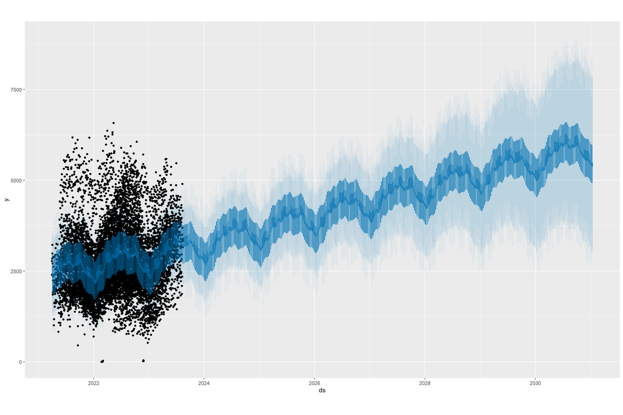

```r
# Creating a future dataframe for predictions on the test data
future <- make_future_dataframe(model_fit, periods = nrow(test_data))

# Making predictions on the test data
forecast <- predict(model_fit, future)

# Visualize the forecast
plot(model_fit, forecast)
```

```r
# Accuracy Metrics
accuracy_metrics <- accuracy(forecast$yhat, test_data$y)
print(accuracy_metrics)
```

```
##                 ME     RMSE      MAE  MPE MAPE
## Test set -393.7426 1300.337 1042.704 -Inf  Inf
```

The average percentage difference between the predicted and actual values is called the Mean Percentage Error, or MPE for short.

These metrics provide insights into the model’s performance, indicating how well the forecasted values align with the observed values. The negative ME suggests an overall overestimation by the model.

## Fitting The model with Regressors

```r
#library(prophet)

# Create a Prophet model
model_reg <- prophet()

# Add additional regressor variables
model_reg <- add_regressor(model_reg, name = "food_service_sales")
model_reg <- add_regressor(model_reg, name = "diesel_sales")
model_reg <- add_regressor(model_reg, name = "unleaded_sales")

# Fit the model with additional regressors
model_reg <- fit.prophet(model_reg, model_df)
```

```
## Disabling daily seasonality. Run prophet with daily.seasonality=TRUE to override this.
```

```r
summary(model_reg)
```

```
##                         Length Class      Mode
## growth                    1    -none-     character
## changepoints             25    POSIXct    numeric
## n.changepoints            1    -none-     numeric
## changepoint.range         1    -none-     numeric
## yearly.seasonality        1    -none-     character
## weekly.seasonality        1    -none-     character
## daily.seasonality         1    -none-     character
## holidays                  0    -none-     NULL
## seasonality.mode          1    -none-     character
## seasonality.prior.scale   1    -none-     numeric
## changepoint.prior.scale   1    -none-     numeric
## holidays.prior.scale      1    -none-     numeric
## mcmc.samples              1    -none-     numeric
## interval.width            1    -none-     numeric
## uncertainty.samples       1    -none-     numeric
## specified.changepoints    1    -none-     logical
## start                     1    POSIXct    numeric
## y.scale                   1    -none-     numeric
## logistic.floor            1    -none-     logical
## t.scale                   1    -none-     numeric
## changepoints.t           25    -none-     numeric
## seasonalities             2    -none-     list
## extra_regressors          3    -none-     list
## country_holidays          0    -none-     NULL
## stan.fit                  4    -none-     list
## params                    6    -none-     list
## history                  65    data.frame list
## history.dates           947    POSIXct    numeric
## train.holiday.names       0    -none-     NULL
## train.component.cols      8    data.frame list
## component.modes           2    -none-     list
## fit.kwargs                0    -none-     list
```

```r
# Make future predictions
future <- make_future_dataframe(model_reg, periods = 365)  # Example: forecast for 365 days

length(model_df$food_service_sales)
```

```
## [1] 13542
```

```r
# Assuming future has fewer rows than model_df$food_service_sales
future$food_service_sales <- head(model_df$food_service_sales, nrow(future))
future$diesel_sales <- head(model_df$diesel_sales, nrow(future))
future$unleaded_sales <- head(model_df$unleaded_sales, nrow(future))

#future$food_service_sales <- model_df$food_service_sales
#future$diesel_sales <- model_df$diesel_sales
#future$unleaded_sales <- model_df$unleaded_sales

forecast <- predict(model_reg, future)

colnames(forecast)
```

```
##  [1] "ds"                              "trend"
##  [3] "additive_terms"                  "additive_terms_lower"
##  [5] "additive_terms_upper"            "diesel_sales"
##  [7] "diesel_sales_lower"              "diesel_sales_upper"
##  [9] "extra_regressors_additive"       "extra_regressors_additive_lower"
## [11] "extra_regressors_additive_upper" "food_service_sales"
## [13] "food_service_sales_lower"        "food_service_sales_upper"
## [15] "unleaded_sales"                  "unleaded_sales_lower"
## [17] "unleaded_sales_upper"            "weekly"
## [19] "weekly_lower"                    "weekly_upper"
## [21] "yearly"                          "yearly_lower"
## [23] "yearly_upper"                    "multiplicative_terms"
## [25] "multiplicative_terms_lower"      "multiplicative_terms_upper"
## [27] "yhat_lower"                      "yhat_upper"
## [29] "trend_lower"                     "trend_upper"
## [31] "yhat"
```

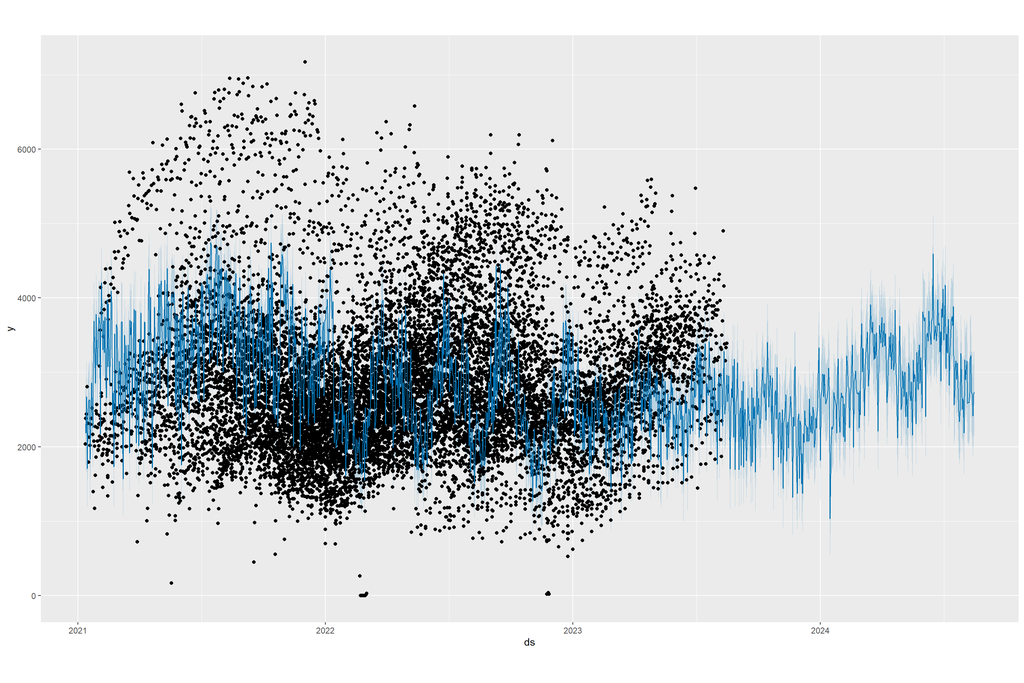

```r
# Visualize forecast
plot(model_reg, forecast)
```

By taking into account these extra variables and utilising Prophet’s ability to include external regressors, this code can produce forecasts that may provide more thorough predictions due to the inclusion of various impacting factors.

## Results

Forecasts for future time periods were produced by applying the Prophet algorithm-based initial forecasting model to the given dataset. Metrics including Mean Error (ME), Root Mean Squared Error (RMSE), Mean Absolute Error (MAE), Mean Percentage Error (MPE), and Mean Absolute Percentage Error (MAPE) were used to evaluate the forecast’s accuracy. The performance of the model and the size of the forecast errors were shown by the precise values of these measures.

Using the Prophet algorithm, a more advanced forecasting model was developed by adding three more regressor variables: “food_service_sales,” “diesel_sales,” and “unleaded_sales.” Using the supplied dataset, the model was trained to produce predictions for upcoming times using both historical data and extra regressor factors.

These code snippets show how to perform time series forecasting using the Prophet model with and without extra regressor variables. With the addition of more regressors, the forecast should be more accurate and complete as a result of taking into account a variety of influencing factors.

# Support Vector Regression Model (SVR)

## Data Preparation

```r
# Load time series data

tdata <- read.csv("time_series_data_msba.csv")

# Check for NAs in the time series data

colSums(is.na(tdata))
```

```
##                                  X capital_projects.soft_opening_date
##                                  0                                  0
##         calendar.calendar_day_date   calendar.fiscal_week_id_for_year
##                                  0                                  0
##               calendar.day_of_week       calendar_information.holiday
##                                  0                                  0
##   calendar_information.type_of_day   daily_yoy_ndt.total_inside_sales
##                                  0                                  0
##   daily_yoy_ndt.total_food_service                             diesel
##                                  0                                  0
##                           unleaded                       site_id_msba
##                                  0                                  0
```

```r
# View Structure of the time series data
str(tdata)
```

```
## 'data.frame':    13908 obs. of  12 variables:
##  $ X                                 : int  1 2 3 4 5 6 7 8 9 10 ...
##  $ capital_projects.soft_opening_date: chr  "2022-06-14" "2022-06-14" "2022-06-14" "2022-06-14" ...
##  $ calendar.calendar_day_date        : chr  "2022-06-17" "2022-06-22" "2022-06-23" "2022-06-26" ...
##  $ calendar.fiscal_week_id_for_year  : int  25 25 25 26 26 26 27 27 27 28 ...
##  $ calendar.day_of_week              : chr  "Friday" "Wednesday" "Thursday" "Sunday" ...
##  $ calendar_information.holiday      : chr  "NONE" "NONE" "NONE" "NONE" ...
##  $ calendar_information.type_of_day  : chr  "WEEKDAY" "WEEKDAY" "WEEKDAY" "WEEKEND" ...
##  $ daily_yoy_ndt.total_inside_sales  : num  2168 2052 2258 1521 1898 ...
##  $ daily_yoy_ndt.total_food_service  : num  862 808 966 542 771 ...
##  $ diesel                            : num  723 730 896 584 852 ...
##  $ unleaded                          : num  1425 1436 1594 1125 1640 ...
##  $ site_id_msba                      : int  24535 24535 24535 24535 24535 24535 24535 24535 24535 24535 ...
```

```r
# Change the names of the time series data columns and replace with the part after the period(.)

colnames <- colnames(tdata)
new_col_names <- sub(".+\\.", "", colnames)
colnames(tdata) <- new_col_names
```

```r
#Convert 'calendar_day_date' to Date format

tdata$calendar_day_date <- as.Date(tdata$calendar_day_date)
```

```r
## Encode the categorical data
convert_to_factors <- function(data) {
  # Get the column names of categorical variables
  categorical_columns <- sapply(data, function(col) is.factor(col) || is.character(col))

  # Convert categorical columns to factors
  data[categorical_columns] <- lapply(data[categorical_columns], as.factor)

  return(data)
}

ts_data <- convert_to_factors(tdata)


# Remove columns which will not effect the time series analysis
ts_data <- ts_data %>% select(-c(`site_id_msba`, `soft_opening_date`))
```

```r
# Scaling Numeric and Integer data columns

# Identify numeric and integer columns
numeric_columns <- sapply(ts_data, is.numeric)
integer_columns <- sapply(ts_data, is.integer)

# Combine numeric and integer columns
columns_to_scale <- numeric_columns | integer_columns

# Apply scaling to selected columns
ts_data[columns_to_scale] <- lapply(ts_data[columns_to_scale], scale)
```

```r
# Split the data into train and test sets.

set.seed(123)
num_rows <- nrow(ts_data)
train_index <- sample(1:num_rows, 0.8 * num_rows)

train_data <- ts_data[train_index, ]
test_data <- ts_data[-train_index, ]
```

## Model Selection - Support Vector Regression & Hyperparamter Tuning

```r
# Create 4 Support Vector Models for each of the target variables

svr_total_inside_sales <- svm(total_inside_sales~., data = train_data, type = "eps-regression", kernel = "radial", epsilon = 0.15)

svr_total_food_service <- svm(total_food_service~., data = train_data, type = "eps-regression", kernel = "radial", epsilon = 0.15)

svr_diesel <- svm(diesel~., data = train_data, type = "eps-regression", kernel = "radial", epsilon = 0.15)

svr_unleaded <- svm(unleaded~., data = train_data, type = "eps-regression", kernel = "radial", epsilon = 0.15)
```

```r
# Perform prediction of each of 4 target variables using test data

predictions_total_inside_sales <- predict(svr_total_inside_sales, test_data)

predictions_total_food_service <- predict(svr_total_food_service, test_data)

predictions_diesel <- predict(svr_diesel, test_data)

predictions_unleaded <- predict(svr_unleaded, test_data)
```

Support Vector Regression is used to find a hyperplane that fits the data points in a high-dimensional space. This hyperplane is determined by maximizing the margin between the data points and the hyperplane, subject to a user-defined tolerance for errors (controlled by a parameter called “epsilon”). For a multivariate time series analysis, SVR, treats the input data as a multivariate time series. Instead of using a single independent variable to predict the target variable, one can use multiple features as input to predict the target variable. SVR, unlike Linear regression takes into consideration non-linearity amongst data points.

## Evaluating Model Performance using MSE/RMSE/R-Squared

```r
#Evaluating model performance by Calculating MSE

mse_total_inside_sales <- mean((predictions_total_inside_sales - test_data$total_inside_sales)^2)
mse_total_food_service <- mean((predictions_total_food_service - test_data$total_food_service)^2)
mse_diesel <- mean((predictions_diesel - test_data$diesel)^2)
mse_unleaded <- mean((predictions_unleaded - test_data$unleaded)^2)


cat("Mean Squared Error for total_inside_sales:", mse_total_inside_sales, "\n")
```

```
## Mean Squared Error for total_inside_sales: 0.1189227
```

```r
cat("Mean Squared Error for total_food_service:", mse_total_food_service, "\n")
```

```
## Mean Squared Error for total_food_service: 0.07742946
```

```r
cat("Mean Squared Error for diesel:", mse_diesel, "\n")
```

```
## Mean Squared Error for diesel: 0.3220052
```

```r
cat("Mean Squared Error for unleaded:",mse_unleaded, "\n")
```

```
## Mean Squared Error for unleaded: 0.6943869
```

```r
#Evaluating model performance by Calculating RMSE

rmse_total_inside_sales <- sqrt(mean((predictions_total_inside_sales - test_data$total_inside_sales)^2))
rmse_total_food_service <- sqrt(mean((predictions_total_food_service - test_data$total_food_service)^2))
rmse_diesel <- sqrt(mean((predictions_diesel - test_data$diesel)^2))
rmse_unleaded <- sqrt(mean((predictions_unleaded - test_data$unleaded)^2))


cat("Root Mean Squared Error for total_inside_sales:", rmse_total_inside_sales, "\n")
```

```
## Root Mean Squared Error for total_inside_sales: 0.3448517
```

```r
cat("Root Mean Squared Error for total_food_service:", rmse_total_food_service, "\n")
```

```
## Root Mean Squared Error for total_food_service: 0.2782615
```

```r
cat("Root Mean Squared Error for diesel:", rmse_diesel, "\n")
```

```
## Root Mean Squared Error for diesel: 0.567455
```

```r
cat("Root Mean Squared Error for unleaded:", rmse_unleaded, "\n")
```

```
## Root Mean Squared Error for unleaded: 0.8332988
```

```r
#Evaluating model performance by Calculating R-Squared

r2_total_inside_sales <- 1 - sum((test_data$total_inside_sales - predictions_total_inside_sales)^2) / sum((test_data$total_inside_sales - mean(test_data$total_inside_sales))^2)

r2_total_food_service <- 1 - sum((test_data$total_food_service - predictions_total_food_service)^2) / sum((test_data$total_food_service - mean(test_data$total_food_service))^2)

r2_diesel <- 1 - sum((test_data$diesel - predictions_diesel)^2) / sum((test_data$diesel - mean(test_data$diesel))^2)

r2_unleaded <- 1 - sum((test_data$unleaded - predictions_unleaded)^2) / sum((test_data$unleaded - mean(test_data$unleaded))^2)


cat("R-Squared for total_inside_sales:", r2_total_inside_sales, "\n")
```

```
## R-Squared for total_inside_sales: 0.8811577
```

```r
cat("R-Squared for total_food_service:", r2_total_food_service, "\n")
```

```
## R-Squared for total_food_service: 0.9205873
```

```r
cat("R-Squared for diesel:", r2_diesel, "\n")
```

```
## R-Squared for diesel: 0.6560366
```

```r
cat("R-Squared for unleaded:", r2_unleaded, "\n")
```

```
## R-Squared for unleaded: 0.3067179
```

## Results

Support vector for individual models has given good results when considering R-Squared. We can observe that the R-squared is highest for total_food_services. Simultaneously the RMSE values for total_food_service is much lower implying the model has been able to reduce error to a great extent.

# Extreme Gradient Boosting (XGBoost)

## Data Preparation

```r
# get desired column names from EDA
fixed_cnames <- colnames(read_csv(paste0("q_data.csv")) %>%
                           mutate(men_toilet_count = NA,
                                  .after = self_check_out) %>%
                           select(-rv_fueling_positions))[c(1:39, 41, 42, 40, 43:52)]
q_data <- read_csv(paste0("qualitative_data_msba.csv")) %>%
  # Remove row index and duplicated columns
  select(-c(1, `RV Lanes Fueling Positions`, `Hi-Flow Lanes Fueling Positions`)) %>%
  # properly encode "None"
  mutate(
    across(
      where(~any(grepl("^N/?A$", ., ignore.case = TRUE))),
      ~replace(., grepl("^N/?A$", ., ignore.case = TRUE), "None")
    )
  ) %>%
  rename_with(~fixed_cnames) %>%
  relocate(site_id) %>%
  # omitting zero-variance variables
  select(-c(fDoor_count, godfathers_pizza, diesel, car_wash,
            ev_charging, non_24_hour, self_check_out))
```

```
## ──────────────────────────────────────────────────────── Delimiter: "," chr
## (27): Lottery, Freal, Bonfire Grill, Pizza, Cinnabon, Godfather’s Pizza,... dbl
## (28): ...1, Open Year, Square Feet, Front Door Count, Years Since Last P...
```

```r
# Calculate standardized day id
day_id_df <- tibble(date = seq(as_date("2021-01-01"), as_date("2023-12-31"), "1 day")) %>%
  # Calculate week_id
  mutate(week_id = yearweek(date, week_start = 5) %>% format("%V") %>% as.numeric(),
         # since the first day of fiscal year 2022 is actually in 2021, special logic must be
         # applied to identify the beginning of the year
         x = case_when(lag(week_id, default = 52) == 52 & week_id == 1 ~ 1),
         year = 2020 + rollapplyr(x, width = n(), FUN = sum, na.rm = TRUE, partial = TRUE)) %>%
  group_by(year) %>%
  mutate(day_id = row_number()) %>%
  select(-x) %>%
  ungroup()

t_series <- read_csv(paste0("t_series.csv")) %>%
  # remove missing store
  filter(site_id != 23065) %>%
  relocate(site_id, date) %>%
  arrange(site_id, date) %>%
  mutate(id = row_number(),
         .before = 1) %>%
  left_join(day_id_df %>%
              select(date, day_id), "date") %>%
  group_by(site_id) %>%
  mutate(first_day_id = first(day_id)) %>%
  ungroup() %>%
  arrange(first_day_id, site_id) %>%
  group_by(site_id) %>%
  # Encode an alternative day_id which can exist in 2 years
  mutate(day_id2 = purrr::accumulate(day_id, ~ifelse(.x < .y, .y, .y + 364)),
         date2 = as_date(as.numeric(as_date("2021-01-01")) + (day_id2 - 1))) %>%
  ungroup() %>%
  select(-c(first_day_id))
merged_data <- t_series %>%
  left_join(q_data,
            "site_id") %>%
  arrange(site_id, date)
```

Maverik expressed the importance of aligning days in a standardized manner, which is why `week_id` is included and why I created a `day_id`.

XGBoost can only handle numeric data. I use dummy variables to handle this.

```r
dummy_targ <- merged_data %>%
  # get character columns
  select(where(is.character)) %>%
  colnames()

# create dummy variables
dummy_df <- dummyVars(~.,
                      merged_data %>%
                        select(all_of(dummy_targ))) %>%
  predict(merged_data %>%
            select(all_of(dummy_targ))) %>%
  as_tibble() %>%
  # Ensure one level for each column is left out
  select(!matches("no(ne)?$"), day_of_weekSunday, day_typeWEEKEND, `traditional_forecourt_layoutIn-Line`)
```

Including features derived from an ARIMA model may prove to be helpful in an XGBoost regressor. The innovation residuals and fitted values are calculated for each sales metric for each site.

```r
mts <- merged_data %>%
  # Convert to wide form
  pivot_longer(inside_sales:unleaded_sales,
               names_to = "met",
               values_to = "sales") %>%
  # create tsibble grouped on site and sales metric
  as_tsibble(index = date, key = c(site_id, met))
```

```r
# fit arima model
mts_fit <- mts %>%
  model(
    arima = ARIMA(sales, stepwise = FALSE)
  )
```

```r
# get desired metrics
mts_aug <- mts_fit %>%
  augment() %>%
  as_tibble() %>%
  pivot_wider(id_cols = c(site_id, date),
              names_from = met,
              values_from = c(.fitted, .innov)) %>%
  # rename output
  rename_with(~gsub("(\\..*?)_(.*)", "\\2\\1", .),
              contains("."))
```

The dummy variables and ARIMA features are incorporated into the model data. Other features were experimented with and omitted in final iterations. XGBoost doesn’t handle dates very well so their components need to be split into separate columns.

```r
mdf <- merged_data %>%
  arrange(site_id, date) %>%
  relocate(id, site_id, day_id) %>%
  relocate(open_year, .after = day_id) %>%
  # Split dates
  mutate(open_month = month(open_date),
         open_day = day(open_date),
         .after = open_year) %>%
  # join ARIMA features
  left_join(mts_aug, c("site_id", "date")) %>%
  mutate(year = year(date),
         month = month(date),
         day = day(date),
         .after = date) %>%
  group_by(site_id) %>%
  # include lagged values of the sales features
  mutate(across(contains("sales"),
                list(l1 = ~. - lag(.),
                     l7 = ~. - lag(., 7)))) %>%
  ungroup() %>%
  # remove undesired columns
  select(-c(date, open_date, day_id2, date2, all_of(dummy_targ))) %>%
  bind_cols(dummy_df)
```

I decided to hold out entire sites when creating the train test splits so that I can plot entire sales history later on as opposed to random, disjoint dates.

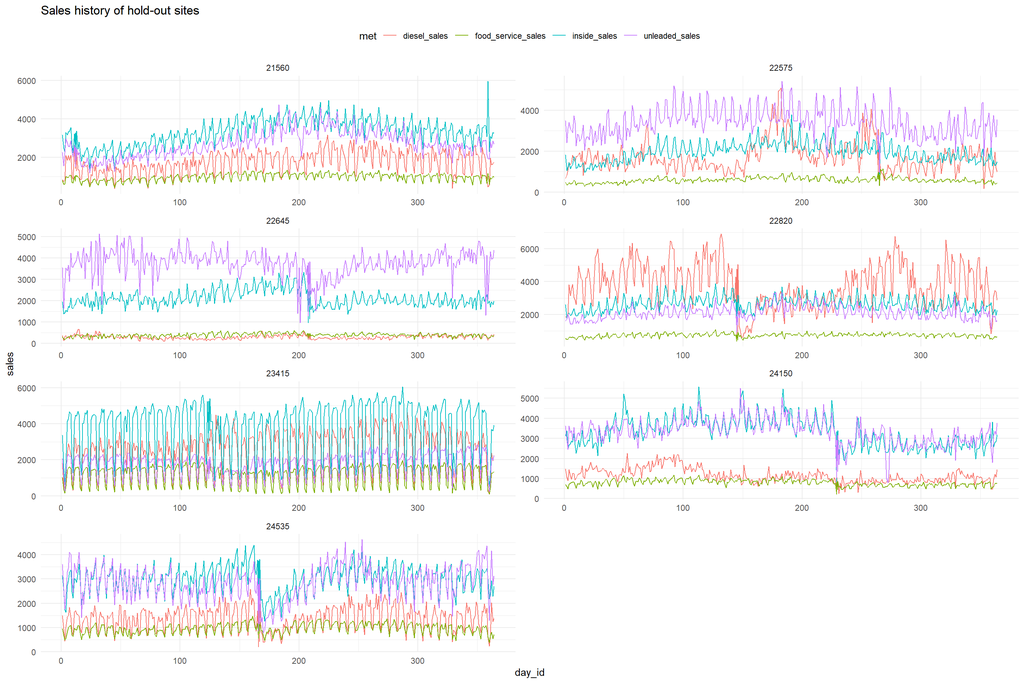

```r
set.seed(1234)
train_sites <- sample(unique(mdf$site_id), 30)


mdf %>%
  filter(!site_id %in% train_sites) %>%
  pivot_longer(inside_sales:unleaded_sales,
               names_to = "met",
               values_to = "sales") %>%
  relocate(met, sales, .after = open_year) %>%
  ggplot() +
  geom_line(aes(day_id, sales, color = met)) +
  facet_rep_wrap(~site_id, repeat.tick.labels = TRUE, scales = "free_y", ncol = 2) +
  theme_minimal() +
  theme(legend.position = "top") +
  labs(title = "Sales history of hold-out sites")
```

Since predictions need to be made for four separate targets, the appropriates sets have to be defined. XGBoost requires a special class to include in `watchlist` so a separate DMatrix is made for each target variable.

```r
# Train
train_all <- mdf %>%
  filter(site_id %in% train_sites)

train_is <- train_all %>%
  select(-c(id, site_id, inside_sales, open_year:day, matches("\\.(fitted|innov)$")))
train_fs <- train_all %>%
  select(-c(id, site_id, food_service_sales, open_year:day, matches("\\.(fitted|innov)$")))
train_d <- train_all %>%
  select(-c(id, site_id, diesel_sales, open_year:day, matches("\\.(fitted|innov)$")))
train_u <- train_all %>%
  select(-c(id, site_id, unleaded_sales, open_year:day, matches("\\.(fitted|innov)$")))

train_df <- train_all %>%
  select(-c(id, site_id, inside_sales:unleaded_sales, open_year:day, matches("\\.(fitted|innov)$")))

# Test
test_all <- mdf %>%
  filter(!site_id %in% train_sites)

test_is <- test_all %>%
  select(-c(id, site_id, inside_sales, open_year:day, matches("\\.(fitted|innov)$")))
test_fs <- test_all %>%
  select(-c(id, site_id, food_service_sales, open_year:day, matches("\\.(fitted|innov)$")))
test_d <- test_all %>%
  select(-c(id, site_id, diesel_sales, open_year:day, matches("\\.(fitted|innov)$")))
test_u <- test_all %>%
  select(-c(id, site_id, unleaded_sales, open_year:day, matches("\\.(fitted|innov)$")))

test_df <- test_all  %>%
  select(-c(id, site_id, inside_sales:unleaded_sales, open_year:day, matches("\\.(fitted|innov)$")))

# Prepare modeling data
train_dmat_is <- xgb.DMatrix(data = as.matrix(train_df), label = train_all$inside_sales)
train_dmat_fs <- xgb.DMatrix(data = as.matrix(train_df), label = train_all$food_service_sales)
train_dmat_d <- xgb.DMatrix(data = as.matrix(train_df), label = train_all$diesel_sales)
train_dmat_u <- xgb.DMatrix(data = as.matrix(train_df), label = train_all$unleaded_sales)

test_dmat_is <- xgb.DMatrix(data = as.matrix(test_df), label = test_all$inside_sales)
test_dmat_fs <- xgb.DMatrix(data = as.matrix(test_df), label = test_all$food_service_sales)
test_dmat_d <- xgb.DMatrix(data = as.matrix(test_df), label = test_all$diesel_sales)
test_dmat_u <- xgb.DMatrix(data = as.matrix(test_df), label = test_all$unleaded_sales)
```

## Modeling

To decide on a final model, I’ll define a tuning grid of 144 hyperparameters to use in 3-fold cross validation. I will implement this first on `inside_sales` and use the best paramters on the other targets.

```r
# Train control
tc <- trainControl(method = "cv",
                   # 3-fold cv
                   number = 3,
                   allowParallel = FALSE,
                   returnResamp = "all",
                   returnData = TRUE,
                   savePredictions = TRUE)

# Hyperparameters ----
params <- expand.grid(eta = c(0.05, 0.01),
                      subsample = c(0.5, 0.8, 1),
                      gamma = c(2, 5, 7),
                      max_depth = c(3, 12),
                      min_child_weight = c(2, 5),
                      colsample_bytree = c(0.5, 0.9),
                      nrounds = 1000)
```

Parallel processing was utilized to save time. Strangely, I repeatedly encountered an error stating “Inconsistent values between `best_tune` and xgb.attr”, but only when running on a Mac. This error never occurred when running on a Windows machine. Given the stochastic nature of XGBoost training, the error didn’t always occur, and thus in part depended on the random seed. This means that if training was attempted after an error, a valid result may be obtained. I used `tryCatch` in the `foreach` loop to keep trying until a model was trained.

```r
# set seed
set.seed(123)
# use 9 cores
cl <- makeForkCluster(8)
registerDoParallel(cl)
# record start time
(xtime1 <- Sys.time())

# Initiate loop
xgb_par <- foreach(i = 1:nrow(params),
                   .packages = c("xgboost", "caret", "tidyverse"),
                   .verbose = TRUE#, .errorhandling = "pass"
) %dopar% {

  # foreach doesn't import xgb.DMatrix objects so they must be defined again here
  train_dmat_is <- xgb.DMatrix(data = as.matrix(train_df), label = train_all$inside_sales)
  test_dmat_is <- xgb.DMatrix(data = as.matrix(test_df), label = test_all$inside_sales)
  set.seed(123)

  # Initialize failed state
  xgb_model <- "failed"

  # keep trying until success
  while(class(xgb_model) == "character"){
    xgb_model <- tryCatch({
      train(
        x = as.data.frame(train_is),
        y = train_all$inside_sales,
        method = "xgbTree",
        watchlist = list(train = train_dmat_is, test = test_dmat_is),
        tuneGrid = params[i,],
        trControl = tc,
        early_stopping_rounds = 20,
        verbose = 0
      )
    }, error = function(e) {
      "failed"
    })
  }
  gc()

  xgb_model

}

# stop cluster
stopCluster(cl)
stopImplicitCluster()
# record run-time
xtime2 <- Sys.time()
xtime2 - xtime1
gc()
```

## CV Evaluation

For each model, I make predictions on the test and train set, obtain performance metrics, combine them all into a dataframe, and take the best results based on each metric.

```r
# Evaluate results ----
tune_res <- lapply(xgb_par,
                   \(x){

                     if("error" %in% class(x)){
                       tibble()
                     } else {
                       train_preds <- predict(x, train_is)
                       train_res <- postResample(train_preds, train_all$inside_sales) %>%
                         as.list() %>%
                         as_tibble() %>%
                         rename_with(~paste0("train_", .))

                       test_preds <- predict(x, test_is)
                       test_res <- postResample(test_preds, test_all$inside_sales) %>%
                         as.list() %>%
                         as_tibble() %>%
                         rename_with(~paste0("test_", .))

                       x$results %>%
                         as_tibble() %>%
                         mutate(train_res,
                                test_res,
                                train_preds = list(train_preds),
                                test_preds = list(test_preds))
                     }


                   }) %>%
  list_rbind() %>%
  relocate(eta:nrounds, .after = test_MAE) %>%
  # determine severity of overfitting by calculating difference between test and train metrics
  mutate(id = row_number(),
         rmse_diff = test_RMSE - train_RMSE,
         rsq_diff = train_Rsquared - test_Rsquared,
         .before = 1)

head(tune_res)
```

| id | rmse_diff | rsq_diff | RMSE | Rsquared | MAE | RMSESD | RsquaredSD | MAESD | train_RMSE | train_Rsquared | train_MAE | test_RMSE | test_Rsquared | test_MAE | eta | subsample | gamma | max_depth | min_child_weight | colsample_bytree | nrounds | train_preds | test_preds |
| --- | --- | --- | --- | --- | --- | --- | --- | --- | --- | --- | --- | --- | --- | --- | --- | --- | --- | --- | --- | --- | --- | --- | --- |
| 1 | -13.644524 | 0.11719006 | 595.0344 | 0.8624582 | 467.1713 | 91.98972 | 0.009916700 | 84.07556 | 623.5697 | 0.8631814 | 489.1008 | 609.9252 | 0.7459914 | 470.5109 | 0.05 | 0.5 | 2 | 3 | 2 | 0.5 | 1000 |  |  |
| 2 | -17.509056 | 0.06811957 | 573.0269 | 0.8689881 | 446.6724 | 63.51960 | 0.003911861 | 54.59276 | 565.3765 | 0.8713218 | 441.0388 | 547.8675 | 0.8032022 | 418.3361 | 0.01 | 0.5 | 2 | 3 | 2 | 0.5 | 1000 |  |  |
| 3 | -13.939187 | 0.11636745 | 584.5055 | 0.8639698 | 456.8237 | 67.38772 | 0.011500650 | 59.78070 | 620.8552 | 0.8623513 | 486.9251 | 606.9160 | 0.7459838 | 470.1434 | 0.05 | 0.8 | 2 | 3 | 2 | 0.5 | 1000 |  |  |
| 4 | -12.146028 | 0.06983314 | 568.0822 | 0.8676920 | 443.1125 | 14.34880 | 0.001289609 | 12.64900 | 542.5523 | 0.8737508 | 420.5978 | 530.4063 | 0.8039177 | 402.8799 | 0.01 | 0.8 | 2 | 3 | 2 | 0.5 | 1000 |  |  |
| 5 | -5.494334 | 0.06147893 | 547.1350 | 0.8695237 | 423.4393 | 108.77281 | 0.007761120 | 92.57816 | 547.2342 | 0.8750678 | 424.4717 | 541.7398 | 0.8135889 | 411.7971 | 0.05 | 1.0 | 2 | 3 | 2 | 0.5 | 1000 |  |  |
| 6 | -8.499114 | 0.07692308 | 643.6255 | 0.8638292 | 513.2591 | 102.20291 | 0.006553518 | 94.63245 | 595.2438 | 0.8720587 | 468.3816 | 586.7447 | 0.7951356 | 451.3046 | 0.01 | 1.0 | 2 | 3 | 2 | 0.5 | 1000 |  |  |

```r
# Get hyperparameters of best 3 RMSE (cv, train, and test) & Rsquared (cv, train, and test),

bind_rows(
  tune_res %>%
    select(id:Rsquared, train_RMSE, train_Rsquared, test_RMSE, test_Rsquared,
           eta:colsample_bytree) %>%
    arrange(RMSE) %>%
    slice_head(n = 3) %>%
    mutate(tvar = "RMSE", .before = 1),

  tune_res %>%
    select(id:Rsquared, train_RMSE, train_Rsquared, test_RMSE, test_Rsquared,
           eta:colsample_bytree) %>%
    arrange(-Rsquared) %>%
    slice_head(n = 3) %>%
    mutate(tvar = "Rsqaured", .before = 1),

  tune_res %>%
    select(id:Rsquared, train_RMSE, train_Rsquared, test_RMSE, test_Rsquared,
           eta:colsample_bytree) %>%
    arrange(test_RMSE) %>%
    slice_head(n = 3) %>%
    mutate(tvar = "test_RMSE", .before = 1),

  tune_res %>%
    select(id:Rsquared, train_RMSE, train_Rsquared, test_RMSE, test_Rsquared,
           eta:colsample_bytree) %>%
    arrange(-test_Rsquared) %>%
    slice_head(n = 3) %>%
    mutate(tvar = "test_Rsquared", .before = 1),

  tune_res %>%
    select(id:Rsquared, train_RMSE, train_Rsquared, test_RMSE, test_Rsquared,
           eta:colsample_bytree) %>%
    arrange(rmse_diff) %>%
    slice_head(n = 3) %>%
    mutate(tvar = "rmse_diff", .before = 1),

  tune_res %>%
    select(id:Rsquared, train_RMSE, train_Rsquared, test_RMSE, test_Rsquared,
           eta:colsample_bytree) %>%
    arrange(rsq_diff) %>%
    slice_head(n = 3) %>%
    mutate(tvar = "rsq_diff", .before = 1)
)
```

| tvar | id | rmse_diff | rsq_diff | RMSE | Rsquared | train_RMSE | train_Rsquared | test_RMSE | test_Rsquared | eta | subsample | gamma | max_depth | min_child_weight | colsample_bytree |
| --- | --- | --- | --- | --- | --- | --- | --- | --- | --- | --- | --- | --- | --- | --- | --- |
| RMSE | 22 | 295.67087 | 0.10093340 | 159.5731 | 0.9749142 | 65.98469 | 0.9962882 | 361.6556 | 0.8953548 | 0.01 | 0.8 | 2 | 12 | 2 | 0.5 |
| RMSE | 130 | 277.39138 | 0.09172814 | 163.3757 | 0.9724189 | 53.21361 | 0.9974006 | 330.6050 | 0.9056725 | 0.01 | 0.8 | 2 | 12 | 5 | 0.9 |
| RMSE | 36 | 328.40281 | 0.11682709 | 165.3198 | 0.9731699 | 57.29052 | 0.9973106 | 385.6933 | 0.8804835 | 0.01 | 1.0 | 7 | 12 | 2 | 0.5 |
| Rsqaured | 22 | 295.67087 | 0.10093340 | 159.5731 | 0.9749142 | 65.98469 | 0.9962882 | 361.6556 | 0.8953548 | 0.01 | 0.8 | 2 | 12 | 2 | 0.5 |
| Rsqaured | 34 | 295.82301 | 0.10078508 | 167.5365 | 0.9735924 | 65.91015 | 0.9962963 | 361.7332 | 0.8955112 | 0.01 | 0.8 | 7 | 12 | 2 | 0.5 |
| Rsqaured | 36 | 328.40281 | 0.11682709 | 165.3198 | 0.9731699 | 57.29052 | 0.9973106 | 385.6933 | 0.8804835 | 0.01 | 1.0 | 7 | 12 | 2 | 0.5 |
| test_RMSE | 98 | 243.40131 | 0.08130800 | 171.1531 | 0.9717035 | 77.55131 | 0.9947856 | 320.9526 | 0.9134776 | 0.01 | 0.5 | 5 | 12 | 2 | 0.9 |
| test_RMSE | 104 | 239.97763 | 0.08454211 | 178.0318 | 0.9704968 | 82.59805 | 0.9942893 | 322.5757 | 0.9097472 | 0.01 | 0.5 | 7 | 12 | 2 | 0.9 |
| test_RMSE | 92 | 253.96801 | 0.08471759 | 174.2672 | 0.9710825 | 68.71296 | 0.9956484 | 322.6810 | 0.9109308 | 0.01 | 0.5 | 2 | 12 | 2 | 0.9 |
| test_Rsquared | 98 | 243.40131 | 0.08130800 | 171.1531 | 0.9717035 | 77.55131 | 0.9947856 | 320.9526 | 0.9134776 | 0.01 | 0.5 | 5 | 12 | 2 | 0.9 |

[output cut: 8 more lines]

```r
# Feature importance
varImp(xgb_par[[22]])
```

```
## xgbTree variable importance
##
##   only 20 most important variables shown (out of 124)
##
##                           Overall
## food_service_sales        100.000
## food_service_sales.fitted  77.725
## unleaded_sales             11.188
## x1_mile_pop                10.804
## pizzaYes                   10.769
## x5_min_pop                  8.152
## unleaded_sales.fitted       7.830
## x1_mile_income              5.163
## open_month                  3.846
## day_id                      3.768
## diesel_sales.fitted         3.610
## parking_spaces              3.429
## inside_sales_l1             3.384
## diesel_sales                3.330
## inside_sales_l7             3.081
## x7_min_pop                  2.899
## square_feet                 2.756
## x1_2_mile_pop               2.393
## open_day                    2.054
## day_typeWEEKDAY             1.905
```

Model 22 yielded the best RMSE and Rsquared in CV, so its hyperparamters will be used to predict the remaining sales metrics.

```r
# Food service
set.seed(123)
xgb_fs <- "failed"

while(class(xgb_fs) == "character"){
  xgb_fs <- tryCatch({
    train(
      x = as.data.frame(train_fs),
      y = train_all$inside_sales,
      method = "xgbTree",
      watchlist = list(train = train_dmat_fs, test = test_dmat_fs),
      tuneGrid = params[22,],
      trControl = tc,
      early_stopping_rounds = 20,
      verbose = 0
    )
  }, error = function(e) {
    "failed"
  })
}

xgb_fs$results

# Diesel
xgb_d <- "failed"

while(class(xgb_d) == "character"){
  xgb_d <- tryCatch({
    train(
      x = as.data.frame(train_d),
      y = train_all$inside_sales,
      method = "xgbTree",
      watchlist = list(train = train_dmat_d, test = test_dmat_d),
      tuneGrid = params[22,],
      trControl = tc,
      early_stopping_rounds = 20,
      verbose = 0
    )
  }, error = function(e) {
    "failed"
  })
}

# Unleaded
xgb_u <- "failed"

while(class(xgb_u) == "character"){
  xgb_u <- tryCatch({
    train(
      x = as.data.frame(train_u),
      y = train_all$inside_sales,
      method = "xgbTree",
      watchlist = list(train = train_dmat_u, test = test_dmat_u),
      tuneGrid = params[22,],
      trControl = tc,
      early_stopping_rounds = 20,
      verbose = 0
    )
  }, error = function(e) {
    "failed"
  })
}
```

```r
# Food service
train_pred_fs <- predict(xgb_fs, train_fs)
test_pred_fs <- predict(xgb_fs, test_fs)
postResample(train_pred_fs, train_all$food_service_sales)
```

```
##       RMSE   Rsquared        MAE
## 33.9781412  0.9956942 24.4870098
```

```r
postResample(test_pred_fs, test_all$food_service_sales)
```

```
##        RMSE    Rsquared         MAE
## 136.1773057   0.8471135 115.7774812
```

```r
varImp(xgb_fs)
```

```
## xgbTree variable importance
##
##   only 20 most important variables shown (out of 112)
##
##                            Overall
## inside_sales               100.000
## diesel_sales                27.762
## x1_mile_pop                 18.108
## x1_2_mile_pop               17.663
## day_typeWEEKDAY              9.309
## x5_min_pop                   8.728
## rv_lanes_fueling_positions   7.136
## unleaded_sales               6.593
## parking_spaces               5.903
## x1_mile_income               3.915
## hi_flow_fueling_positions    3.799
## rv_lanesYes                  3.585
## day_typeWEEKEND              2.771
## x1_2_mile_income             2.758
## inside_sales.fitted_l1       2.693
## day_id                       2.662
## food_service_sales_l1        2.432
## x7_min_pop                   2.407
## food_service_sales_l7        2.144
## x1_2_mile_emp                2.067
```

```r
# Diesel
train_pred_d <- predict(xgb_d, train_d)
test_pred_d <- predict(xgb_d, test_d)
postResample(train_pred_d, train_all$diesel_sales)
```

```
##        RMSE    Rsquared         MAE
## 737.3965079   0.9864328 401.7019454
```

```r
postResample(test_pred_d, test_all$diesel_sales)
```

```
##         RMSE     Rsquared          MAE
## 1313.6496612    0.1816536  991.0482281
```

```r
varImp(xgb_d)
```

```
## xgbTree variable importance
##
##   only 20 most important variables shown (out of 112)
##
##                               Overall
## hi_flow_fueling_positions     100.000
## men_toilet_count               46.937
## men_urinal_count               46.313
## inside_sales                   20.086
## women_toilet_count             16.409
## food_service_sales             11.805
## rv_lanes_fueling_positions      8.109
## parking_spaces                  6.129
## day_typeWEEKDAY                 5.394
## unleaded_sales                  4.223
## women_sink_count                4.117
## day_id                          3.398
## day_typeWEEKEND                 3.394
## x1_mile_pop                     3.256
## traditional_fueling_positions   2.918
## x1_mile_emp                     2.727
## x1_2_mile_emp                   2.725
## hi_flow_rv_lanesYes             2.238
## x5_min_emp                      2.082
## diesel_sales_l7                 1.827
```

```r
# Unleaded
train_pred_u <- predict(xgb_u, train_u)
test_pred_u <- predict(xgb_u, test_u)
postResample(train_pred_d, train_all$unleaded_sales)
```

```
##         RMSE     Rsquared          MAE
## 2.095876e+03 3.681041e-02 1.562379e+03
```

```r
postResample(test_pred_d, test_all$unleaded_sales)
```

```
##         RMSE     Rsquared          MAE
## 1.984768e+03 5.617575e-04 1.641709e+03
```

```r
varImp(xgb_u)
```

```
## xgbTree variable importance
##
##   only 20 most important variables shown (out of 112)
##
##                    Overall
## diesel_sales        100.00
## men_toilet_count     92.84
## parking_spaces       87.53
## inside_sales         83.51
## x5_min_emp           67.27
## x1_mile_pop          61.21
## x5_min_pop           40.68
## x7_min_emp           39.29
## unleaded_sales_l7    35.06
## x1_mile_emp          28.66
## food_service_sales   28.39
## women_sink_count     25.79
## day_id               24.65
## x5_min_inc           23.39
## x1_mile_income       21.24
## unleaded_sales_l1    21.13
## x7_min_inc           20.50
## x1_2_mile_emp        14.88
## bonfire_grillYes     13.28
## x7_min_pop           11.66
```

## XGBoost Results

What works for one sales metric does not necessarily work for the others. While it’s very computationally expensive, parameter tuning for each sales metric would likely yield the best results. Not surpisingly, each sales metric is fairly predictive of the others. `men_toilet_count` offered an unexpected contribution which may indicate existence of some other confounding explanatory variable.

# ARIMA/ETS Ensemble

```r
# Load packages
library(tidyverse)
library(lubridate)
library(zoo)
library(fpp3)
library(doParallel)
library(caret)
library(xgboost)
```

## Data preparation

```r
# get desired column names from EDA
fixed_cnames <- colnames(read_csv(paste0("q_data.csv")) %>%
                           mutate(men_toilet_count = NA,
                                  .after = self_check_out) %>%
                           select(-rv_fueling_positions))[c(1:39, 41, 42, 40, 43:52)]
q_data <- read_csv(paste0("qualitative_data_msba.csv")) %>%
  # Remove row index and duplicated columns
  select(-c(1, `RV Lanes Fueling Positions`, `Hi-Flow Lanes Fueling Positions`)) %>%
  # properly encode "None"
  mutate(
    across(
      where(~any(grepl("^N/?A$", ., ignore.case = TRUE))),
      ~replace(., grepl("^N/?A$", ., ignore.case = TRUE), "None")
    )
  ) %>%
  rename_with(~fixed_cnames) %>%
  relocate(site_id) %>%
  # omitting zero-variance variables
  select(-c(fDoor_count, godfathers_pizza, diesel, car_wash,
            ev_charging, non_24_hour, self_check_out))
```

```
## ──────────────────────────────────────────────────────── Delimiter: "," chr
## (27): Lottery, Freal, Bonfire Grill, Pizza, Cinnabon, Godfather’s Pizza,... dbl
## (28): ...1, Open Year, Square Feet, Front Door Count, Years Since Last P...
```

```r
# Calculate standardized day id
day_id_df <- tibble(date = seq(as_date("2021-01-01"), as_date("2023-12-31"), "1 day")) %>%
  # Calculate week_id
  mutate(week_id = yearweek(date, week_start = 5) %>% format("%V") %>% as.numeric(),
         # since the first day of fiscal year 2022 is actually in 2021, special logic must be
         # applied to identify the beginning of the year
         x = case_when(lag(week_id, default = 52) == 52 & week_id == 1 ~ 1),
         year = 2020 + rollapplyr(x, width = n(), FUN = sum, na.rm = TRUE, partial = TRUE)) %>%
  group_by(year) %>%
  mutate(day_id = row_number()) %>%
  select(-x) %>%
  ungroup()

t_series <- read_csv(paste0("t_series.csv")) %>%
  # remove missing store
  filter(site_id != 23065) %>%
  relocate(site_id, date) %>%
  arrange(site_id, date) %>%
  mutate(id = row_number(),
         .before = 1) %>%
  left_join(day_id_df %>%
              select(date, day_id), "date") %>%
  group_by(site_id) %>%
  mutate(first_day_id = first(day_id)) %>%
  ungroup() %>%
  arrange(first_day_id, site_id) %>%
  group_by(site_id) %>%
  # Encode an alternative day_id which can exist in 2 years
  mutate(day_id2 = purrr::accumulate(day_id, ~ifelse(.x < .y, .y, .y + 364)),
         date2 = as_date(as.numeric(as_date("2021-01-01")) + (day_id2 - 1))) %>%
  ungroup() %>%
  select(-c(first_day_id))
merged_data <- t_series %>%
  # Join time series and qualitative data
  left_join(q_data,
            "site_id") %>%
  arrange(site_id, date) %>%
  # create observation index variable
  group_by(site_id) %>%
  mutate(start_id = row_number(),
         .before = 2) %>%
  ungroup()
```

I struggled to get the models available in the `fpp3` package to behave as expected when the “index” of a created tsibble was not a native date object, so instead of using `day_id2` as the index in the tsibble, I created `date2` which corresponds directly to `day_id2` but forces the assumption that every site opened in the same year.

## Modeling

- ARIMA
- Regression with ARIMA regressors
- ETS

This implementation from the `fpp3` package allows for automatic selection of each model’s component parts that provide the best fit. While this is a very computationally expensive approach, it is still practical for business implementation. To speed up the process, I’ve elected to compute in parallel using the `doParallel` package.

```r
# choose 5 random sites
set.seed(123)
fe_sites2 <- sample(unique(merged_data$site_id), 5)

# establish 10-core cluster
cl <- makeCluster(10)
registerDoParallel(cl)
(xtime1 <- Sys.time())

# loop over each day
fit_all <- foreach(i = 1:366,
                   .packages = c("tidyverse", "fpp3"),
                   .combine = "bind_rows") %:%
  # loop over each sample site
  foreach(j = fe_sites2,
          .packages = c("tidyverse", "fpp3"),
          .combine = "bind_rows")  %dopar%{

            # subset site and training days
            ox <- merged_data %>%
              filter(site_id == j,
                     start_id <= i) %>%
              distinct(site_id, day_id, day_id2, .keep_all = TRUE) %>%
              select(start_id, site_id, day_id, day_id2, date, date2,
                     holiday, day_of_week, day_type, ends_with("sales")) %>%
              # convert to long form
              pivot_longer(inside_sales:unleaded_sales,
                           names_to = "tvar",
                           values_to = "sales") %>%
              arrange(site_id, tvar, start_id) %>%
              # create tsibble with appropriate key and index
              as_tsibble(index = date2, key = c(site_id, tvar)) %>%
              # define models
              model(arima1 = ARIMA(sales), # ARIMA
                    arima2 = ARIMA(sales ~ season("week")), # Regression with ARIAM regressors
                    ets = ETS(sales)) %>% # ETS
              # log iteration information
              mutate(site_id = j,
                     start_init = i,
                     .before = 1) %>%
              mable(key = c(site_id, start_init, tvar), model = c(arima1, arima2, ets))


            gc()

            ox
          }

stopCluster(cl)
xtime2 <- Sys.time()
xtime2 - xtime1

# create tsibble of sampled sites in format compatible with fitted models
base_all <- merged_data %>%
  filter(site_id %in% fe_sites2) %>%
  distinct(site_id, day_id, day_id2, .keep_all = TRUE) %>%
  select(start_id, site_id, day_id, day_id2, date, date2,
         holiday, day_of_week, day_type, ends_with("sales")) %>%
  pivot_longer(inside_sales:unleaded_sales,
               names_to = "tvar",
               values_to = "sales") %>%
  arrange(site_id, tvar, start_id) %>%
  as_tsibble(index = date2, key = c(site_id, tvar))

# for each site, sales metric, and day, calculate cumulative sales and remaining sales
ppdf_all <- base_all %>%
  as_tibble() %>%
  group_by(site_id, tvar) %>%
  group_modify(~{
    lapply(.x$start_id,
           \(xx){
             .x %>%
               group_by(prd = ifelse(start_id <= xx, "pre", "post")) %>%
               summarise(sales = sum(sales)) %>%
               mutate(start_id = xx,
                      .before = 1)
           }) %>%
      list_rbind()
  }) %>%
  ungroup() %>%
  pivot_wider(names_from = prd,
              values_from = sales) %>%
  mutate(sales = pre + post)

# Make daily forecasts for each site and training start day
fc_all <- fit_all %>%
  filter(start_init <= 365) %>%
  rowwise() %>%
  group_map(~{
    si <- .x$start_init

    .x %>%
      mable(key = c(site_id, tvar), model = c(arima1, arima2, ets)) %>%
      forecast(base_all %>%
                 filter(start_id > si)) %>%
      left_join(base_all %>%
                  filter(start_id > si) %>%
                  select(site_id, date2, sales_obs = sales), c("site_id", "tvar", "date2")) %>%
      group_by(site_id, .model) %>%
      # calculate performance metrics for each site/training start
      mutate(start_init = si,
             er = sales_obs - .mean,
             rmse = RMSE(sales_obs, .mean),
             mape = MAPE(er, sales_obs)) %>%
      relocate(start_init, .after = site_id) %>%
      ungroup()

  }) %>%
  list_rbind()

# get total year performance metrics
fc_all2 <- fc_all %>%
  filter(!is.na(.mean)) %>%
  as_tibble() %>%
  group_by(tvar, .model, site_id, start_init) %>%
  # get annual for each sales metric, model, site, training start combination
  summarise(fc = sum(.mean)) %>%
  # join cumulative/remaning truth data
  left_join(ppdf_all %>%
              select(site_id, tvar, start_init = start_id,
                     pre, post, sales),
            c("site_id", "start_init", "tvar")) %>%
  mutate(tpred = fc + pre,
         er = sales - tpred,
         .after = post) %>%
  relocate(er, .after = last_col()) %>%
  group_by(tvar, .model) %>%
  # aggregate metric for each sales metric and model
  arrange(tvar, start_init) %>%
  mutate(er = sales - tpred,
         rmse = RMSE(tpred, sales),
         mae = MAE(tpred, sales),
         mape = MAPE(er, sales),
         mape_step = (abs(tpred - sales)/sales) * 100,
         # get "rolling" RMSE
         rmse_roll = sapply(start_init,
                            \(xx){RMSE(tpred[start_init >= xx], sales[start_init >= xx])}),
         # get "rolling" MAPE
         mape_roll = sapply(start_init,
                            \(xx){mean(mape_step[start_init >= xx])}),
         # get "rolling" MAE
         mae_roll = sapply(start_init,
                           \(xx){MAE(tpred[start_init >= xx], sales[start_init >= xx])})

  )
```

```r
fc_all2 %>%
  # Select training start day that match Maverik's benchmarks
  filter(start_init %in% c(14, 21, 183, 300)) %>%
  ungroup() %>%
  distinct(tvar, start_init, .model, .keep_all = TRUE) %>%
  arrange(match(tvar, c("inside_sales", "food_service", "diesel", "unleaded")), start_init, rmse) %>%
  select(tvar, start_init, .model, rmse_roll, mape_roll, mae_roll, rmse, mape, mae) %>%
  group_by(tvar, start_init) %>%
  # subset best performing instances
  filter(rmse_roll == min(rmse_roll) | mape_roll == min(mape_roll)) %>%
  ungroup() %>%
  arrange(match(tvar, c("inside_sales", "food_service_sales", "diesel_sales", "unleaded_sales")),
          start_init) %>%
  # make output more readable
  mutate(start_init = case_match(start_init,
                                 14 ~ "2 weeks",
                                 21 ~ "3 weeks",
                                 183 ~ "6 months",
                                 300 ~ "300 days"),
         tvar = paste(tvar, start_init)) %>%
  select(tvar, rmse_roll, mape_roll) %>%
  # prevent scientific notation output
  mutate(across(c(rmse_roll, mape_roll), ~as.character(round(., 2)))) %>%
  filter(!grepl("300", tvar))
```

| tvar | rmse_roll | mape_roll |
| --- | --- | --- |
| inside_sales 2 weeks | 252118.87 | 7.66 |
| inside_sales 3 weeks | 251231.92 | 7.4 |
| inside_sales 6 months | 49936.63 | 3.23 |
| food_service_sales 2 weeks | 50574.18 | 5.49 |
| food_service_sales 3 weeks | 50294.34 | 5.27 |
| food_service_sales 3 weeks | 34362.14 | 5.79 |
| food_service_sales 6 months | 11035.42 | 2.8 |
| diesel_sales 2 weeks | 223947.08 | 11.52 |
| diesel_sales 3 weeks | 220710.58 | 11.28 |
| diesel_sales 6 months | 35884.66 | 3.51 |

[output cut: 5 more lines]

# Results

We have only used the time series data for this model because the qualitative data was not highly co-related while the target variables were co-related within themselves.

Although SVR yielded the best RMSE, the ARIMA/ETS ensemble outperformed Maverik’s benchmarks and possesses much greater versatility and the ability to update models as new data is observed to produce daily forecasts. For these reasons, we recommend Maverik move forward with the ensemble model.

While we were able to devise these models, more data and time would have resulted in better results. There is likely untapped potential in the other models that could be unleashed with more time and experimentation. Some models require massive computational resources to be sure the best parameters are utilised.

# Member Contribution

- Disha Tapadiya
  - Prophet Model
- Debayan Dutta
  - SVR Model
- Kalyani Joshi
  - VAR Model
- Che Diaz Fadel
  - XGBoost Model
  - ARIMA/ETS Ensemble
  - Notebook aggregation